# Modern Data Mining, HW 3

Group Member Kateryna Suprun

Group Member Hannah Xiao

Group Member Kyle Liao

Due: 11:59Pm, 2/26, 2023

# 1 Overview

Multiple regression is one of the most popular methods used in statistics as well as in machine learning. We use linear models as a working model for its simplicity and interpretability. It is important that we use domain knowledge as much as we could to determine the form of the response as well as the function format for the factors. Then, when we have many possible features to be included in the working model it is inevitable that we need to choose a best possible model with a sensible criterion. `Cp`, `BIC` and regularizations such as LASSO are introduced. Be aware that if a model selection is done formally or informally, the inferences obtained with the final `lm()` fit may not be valid. Some adjustment will be needed. This last step is beyond the scope of this class. Check the current research line that Linda and collaborators are working on.

This homework consists of two parts: the first one is an exercise (you will feel it being a toy example after the covid case study) to get familiar with model selection skills such as, `Cp` and `BIC`. The main job is a rather involved case study about devastating covid19 pandemic. Please read through the case study first. This project is for sure a great one listed in your CV.

For covid case study, the major time and effort would be needed in EDA portion.

## 1.1 Objectives

- Model building process
- Methods
  - Model selection
    - All subsets
    - Forward/Backward
  - Regularization
    - LASSO (L1 penalty)
    - Ridge (L2 penalty)
    - Elastic net
- Understand the criteria
  - `Cp`
  - Testing Errors
  - `BIC`
  - `K fold Cross Validation`
  - `LASSO`
- Packages
  - `lm()`, `Anova`
  - `regsubsets()`
  - `glmnet()` & `cv.glmnet()`

# 2 Review materials

- Study lecture: Model selection
- Study lecture: Regularization
- Study lecture: Multiple regression

Review the code and concepts covered during lectures: multiple regression, model selection and penalized regression through elastic net.

# 3 Homework 2, Case study 3: Auto data set

This question utilizes the `Auto` dataset from ISLR. The original dataset contains 408 observations about cars. It is similar to the CARS dataset that we use in our lectures. To get the data, first install the package ISLR. The `Auto` dataset should be loaded automatically. We’ll use this dataset to practice the methods learn so far. Original data source is here: https://archive.ics.uci.edu/ml/datasets/auto+mpg

Get familiar with this dataset first. Tip: you can use the command `?ISLR::Auto` to view a description of the dataset.

## 3.1 EDA

Explore the data, with particular focus on pairwise plots and summary statistics. Briefly summarize your findings and any peculiarities in the data.

If you haven’t done this as part of the homework 2, please attach it here.

```r
summary(Auto)
```

```
##       mpg         cylinders     displacement   horsepower        weight
##  Min.   : 9.0   Min.   :3.00   Min.   : 68   Min.   : 46.0   Min.   :1613
##  1st Qu.:17.0   1st Qu.:4.00   1st Qu.:105   1st Qu.: 75.0   1st Qu.:2225
##  Median :22.8   Median :4.00   Median :151   Median : 93.5   Median :2804
##  Mean   :23.4   Mean   :5.47   Mean   :194   Mean   :104.5   Mean   :2978
##  3rd Qu.:29.0   3rd Qu.:8.00   3rd Qu.:276   3rd Qu.:126.0   3rd Qu.:3615
##  Max.   :46.6   Max.   :8.00   Max.   :455   Max.   :230.0   Max.   :5140
##
##   acceleration       year        origin                     name
##  Min.   : 8.0   Min.   :70   Min.   :1.00   amc matador       :  5
##  1st Qu.:13.8   1st Qu.:73   1st Qu.:1.00   ford pinto        :  5
##  Median :15.5   Median :76   Median :1.00   toyota corolla    :  5
##  Mean   :15.5   Mean   :76   Mean   :1.58   amc gremlin       :  4
##  3rd Qu.:17.0   3rd Qu.:79   3rd Qu.:2.00   amc hornet        :  4
##  Max.   :24.8   Max.   :82   Max.   :3.00   chevrolet chevette:  4
##                                             (Other)           :365
```

```r
#install.packages('GGally')
library(GGally)
library(ggplot2)
```

```r
unique(Auto$mpg)
```

```
##   [1] 18.0 15.0 16.0 17.0 14.0 24.0 22.0 21.0 27.0 26.0 25.0 10.0 11.0  9.0 28.0
##  [16] 19.0 12.0 13.0 23.0 30.0 31.0 35.0 20.0 29.0 32.0 33.0 17.5 15.5 14.5 22.5
##  [31] 24.5 18.5 29.5 26.5 16.5 31.5 36.0 25.5 33.5 20.5 30.5 21.5 43.1 36.1 32.8
##  [46] 39.4 19.9 19.4 20.2 19.2 25.1 20.6 20.8 18.6 18.1 17.7 27.5 27.2 30.9 21.1
##  [61] 23.2 23.8 23.9 20.3 21.6 16.2 19.8 22.3 17.6 18.2 16.9 31.9 34.1 35.7 27.4
##  [76] 25.4 34.2 34.5 31.8 37.3 28.4 28.8 26.8 41.5 38.1 32.1 37.2 26.4 24.3 19.1
##  [91] 34.3 29.8 31.3 37.0 32.2 46.6 27.9 40.8 44.3 43.4 36.4 44.6 33.8 32.7 23.7
## [106] 32.4 26.6 25.8 23.5 39.1 39.0 35.1 32.3 37.7 34.7 34.4 29.9 33.7 32.9 31.6
## [121] 28.1 30.7 24.2 22.4 34.0 38.0 44.0
```

```r
unique(Auto$cylinders)
```

```
## [1] 8 4 6 3 5
```

```r
unique(Auto$displacement)
```

```
##  [1] 307.0 350.0 318.0 304.0 302.0 429.0 454.0 440.0 455.0 390.0 383.0 340.0
## [13] 400.0 113.0 198.0 199.0 200.0  97.0 110.0 107.0 104.0 121.0 360.0 140.0
## [25] 232.0 225.0 250.0 351.0 258.0 122.0 116.0  79.0  88.0  71.0  72.0  91.0
## [37]  97.5  70.0 120.0  96.0  98.0 108.0 155.0  68.0 114.0 156.0  76.0  83.0
## [49]  90.0 231.0 262.0 134.0 119.0 171.0 115.0 101.0 305.0  85.0 130.0 168.0
## [61] 111.0 260.0 151.0 146.0  80.0  78.0 105.0 131.0 163.0  89.0 267.0  86.0
## [73] 183.0 141.0 173.0 135.0  81.0 145.0 112.0 181.0 144.0
```

```r
unique(Auto$horsepower)
```

```
##  [1] 130 165 150 140 198 220 215 225 190 170 160  95  97  85  88  46  87  90 113
## [20] 200 210 193 100 105 175 153 180 110  72  86  70  76  65  69  60  80  54 208
## [39] 155 112  92 145 137 158 167  94 107 230  49  75  91 122  67  83  78  52  61
## [58]  93 148 129  96  71  98 115  53  81  79 120 152 102 108  68  58 149  89  63
## [77]  48  66 139 103 125 133 138 135 142  77  62 132  84  64  74 116  82
```

```r
unique(Auto$weight)
```

```
##   [1] 3504 3693 3436 3433 3449 4341 4354 4312 4425 3850 3563 3609 3761 3086 2372
##  [16] 2833 2774 2587 2130 1835 2672 2430 2375 2234 2648 4615 4376 4382 4732 2264
##  [31] 2228 2634 3439 3329 3302 3288 4209 4464 4154 4096 4955 4746 5140 2962 2408
##  [46] 3282 3139 2220 2123 2074 2065 1773 1613 1834 1955 2278 2126 2254 2226 4274
##  [61] 4385 4135 4129 3672 4633 4502 4456 4422 2330 3892 4098 4294 4077 2933 2511
##  [76] 2979 2189 2395 2288 2506 2164 2100 4100 3988 4042 3777 4952 4363 4237 4735
##  [91] 4951 3821 3121 3278 2945 3021 2904 1950 4997 4906 4654 4499 2789 2279 2401
## [106] 2379 2124 2310 2472 2265 4082 4278 1867 2158 2582 2868 3399 2660 2807 3664
## [121] 3102 2901 3336 2451 1836 2542 3781 3632 3613 4141 4699 4457 4638 4257 2219
## [136] 1963 2300 1649 2003 2125 2108 2246 2489 2391 2000 3264 3459 3432 3158 4668
## [151] 4440 4498 4657 3907 3897 3730 3785 3039 3221 3169 2171 2639 2914 2592 2702
## [166] 2223 2545 2984 1937 3211 2694 2957 2671 1795 2464 2572 2255 2202 4215 4190
## [181] 3962 3233 3353 3012 3085 2035 3651 3574 3645 3193 1825 1990 2155 2565 3150
## [196] 3940 3270 2930 3820 4380 4055 3870 3755 2045 1945 3880 4060 4140 4295 3520
## [211] 3425 3630 3525 4220 4165 4325 4335 1940 2740 2755 2051 2075 1985 2190 2815
## [226] 2600 2720 1800 2070 3365 3735 3570 3535 3155 2965 3430 3210 3380 3070 3620
## [241] 3410 3445 3205 4080 2560 2230 2515 2745 2855 2405 2830 3140 2795 2135 3245
## [256] 2990 2890 3265 3360 3840 3725 3955 3830 4360 4054 3605 1925 1975 1915 2670
## [271] 3530 3900 3190 3420 2200 2150 2020 2595 2700 2556 2144 1968 2120 2019 2678
## [286] 2870 3003 3381 2188 2711 2434 2110 2800 2085 2335 2950 3250 1850 2145 1845
## [301] 2910 2420 2500 2290 2490 2635 2620 2725 2385 1755 1875 1760 2050 2215 2380
## [316] 2210 2350 2615 3230 3160 2900 3415 3060 3465 2605 2640 2575 2525 2735 2865
## [331] 1980 2025 1970 2160 2205 2245 1965 1995 3015 2585 2835 2665 2370 2790 2295
## [346] 2625
```

```r
unique(Auto$acceleration)
```

```
##  [1] 12.0 11.5 11.0 10.5 10.0  9.0  8.5  8.0  9.5 15.0 15.5 16.0 14.5 20.5 17.5
## [16] 12.5 14.0 13.5 18.5 13.0 19.0 19.5 18.0 17.0 23.5 16.5 21.0 16.9 14.9 17.7
## [31] 15.3 13.9 12.8 15.4 17.6 22.2 22.1 14.2 17.4 16.2 17.8 12.2 16.4 13.6 15.7
## [46] 13.2 21.9 16.7 12.1 14.8 18.6 16.8 13.7 11.1 11.4 18.2 15.8 15.9 14.1 21.5
## [61] 14.4 19.4 19.2 17.2 18.7 15.1 13.4 11.2 14.7 16.6 17.3 15.2 14.3 20.1 24.8
## [76] 11.3 12.9 18.8 18.1 17.9 21.7 23.7 19.9 21.8 13.8 12.6 16.1 20.7 18.3 20.4
## [91] 19.6 17.1 15.6 24.6 11.6
```

```r
unique(Auto$year)
```

```
##  [1] 70 71 72 73 74 75 76 77 78 79 80 81 82
```

```r
unique(Auto$origin)
```

```
## [1] 1 3 2
```

```r
unique(Auto$name)
```

```
##   [1] chevrolet chevelle malibu            buick skylark 320
##   [3] plymouth satellite                   amc rebel sst
##   [5] ford torino                          ford galaxie 500
##   [7] chevrolet impala                     plymouth fury iii
##   [9] pontiac catalina                     amc ambassador dpl
##  [11] dodge challenger se                  plymouth 'cuda 340
##  [13] chevrolet monte carlo                buick estate wagon (sw)
##  [15] toyota corona mark ii                plymouth duster
##  [17] amc hornet                           ford maverick
##  [19] datsun pl510                         volkswagen 1131 deluxe sedan
##  [21] peugeot 504                          audi 100 ls
##  [23] saab 99e                             bmw 2002
##  [25] amc gremlin                          ford f250
##  [27] chevy c20                            dodge d200
##  [29] hi 1200d                             chevrolet vega 2300
```

[output cut: 137 more lines]

```r
head(Auto)
```

```
##   mpg cylinders displacement horsepower weight acceleration year origin
## 1  18         8          307        130   3504         12.0   70      1
## 2  15         8          350        165   3693         11.5   70      1
## 3  18         8          318        150   3436         11.0   70      1
## 4  16         8          304        150   3433         12.0   70      1
## 5  17         8          302        140   3449         10.5   70      1
## 6  15         8          429        198   4341         10.0   70      1
##                        name
## 1 chevrolet chevelle malibu
## 2         buick skylark 320
## 3        plymouth satellite
## 4             amc rebel sst
## 5               ford torino
## 6          ford galaxie 500
```

```r
names(Auto)
```

```
## [1] "mpg"          "cylinders"    "displacement" "horsepower"   "weight"
## [6] "acceleration" "year"         "origin"       "name"
```

There do not seem to be any missing values or incorrect entries.

## 3.2 What effect does `time` have on `MPG`?

1. Start with a simple regression of `mpg` vs. `year` and report R’s `summary` output. Is `year` a significant variable at the .05 level? State what effect `year` has on `mpg`, if any, according to this model.

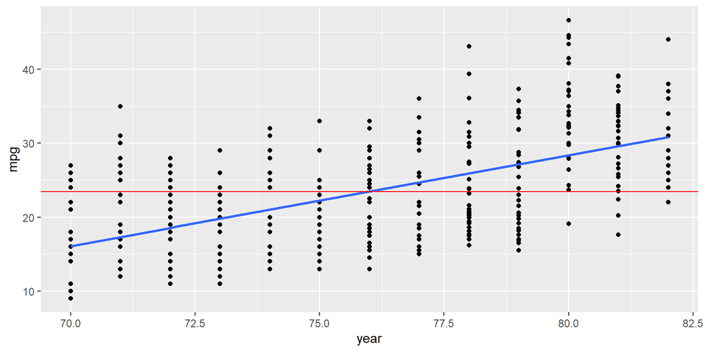

```r
fit1 <- lm(mpg ~ year, data = Auto)    # model specification response ~ x1,..
ggplot(Auto, aes(x = year , y = mpg)) +
  geom_point() +
  geom_smooth(method="lm",se=F) +
geom_hline(aes(yintercept = mean(mpg)), color = "red")
```

```r
fit1 <-  lm(mpg ~ year, data = Auto)  # model one
summary(fit1)
```

```
##
## Call:
## lm(formula = mpg ~ year, data = Auto)
##
## Residuals:
##     Min      1Q  Median      3Q     Max
## -12.021  -5.441  -0.441   4.974  18.209
##
## Coefficients:
##             Estimate Std. Error t value Pr(>|t|)
## (Intercept) -70.0117     6.6452   -10.5   <2e-16 ***
## year          1.2300     0.0874    14.1   <2e-16 ***
## ---
## Signif. codes:  0 '***' 0.001 '**' 0.01 '*' 0.05 '.' 0.1 ' ' 1
##
## Residual standard error: 6.36 on 390 degrees of freedom
## Multiple R-squared:  0.337,  Adjusted R-squared:  0.335
## F-statistic:  198 on 1 and 390 DF,  p-value: <2e-16
```

These results indicate that year is a significant variable on at the 0.05 level because Pt(>|t|) = <2e-16.

2. Add `horsepower` on top of the variable `year` to your linear model. Is `year` still a significant variable at the .05 level? Give a precise interpretation of the `year`’s effect found here.

```r
#install.packages(stargazer)
library('stargazer')
fit2 <- lm(mpg ~ year + horsepower, data = Auto)
summary(fit2)
```

```
##
## Call:
## lm(formula = mpg ~ year + horsepower, data = Auto)
##
## Residuals:
##     Min      1Q  Median      3Q     Max
## -12.077  -3.078  -0.431   2.588  15.315
##
## Coefficients:
##              Estimate Std. Error t value Pr(>|t|)
## (Intercept) -12.73917    5.34903   -2.38    0.018 *
## year          0.65727    0.06626    9.92   <2e-16 ***
## horsepower   -0.13165    0.00634  -20.76   <2e-16 ***
## ---
## Signif. codes:  0 '***' 0.001 '**' 0.01 '*' 0.05 '.' 0.1 ' ' 1
##
## Residual standard error: 4.39 on 389 degrees of freedom
## Multiple R-squared:  0.685,  Adjusted R-squared:  0.684
## F-statistic:  424 on 2 and 389 DF,  p-value: <2e-16
```

We can see that t value of horsepower is greater in magnitude than t value of the variable year, which indicates that horsepower has more effect on mpg than year.

Results also indicate that holding year variable constant, an increase in one unit of horsepower leads to decrease by 0.13165 in mpg. When holding horsepower variable constant, an increase in one unit of year leads to increase by 0.65727 in mpg.

the model equation can be as follows:

$$mpg = -12.73917 + 0.65727*year -
0.13165*horsepower$$

Testing whether year is still a significant variable:

We will assume that the effect of year on mpg is the same regardless of horsepower of the car

```r
data1<-Auto
fit1.no.interaction <- lm(mpg ~ horsepower + year, data1)
summary(fit1.no.interaction)
```

```
##
## Call:
## lm(formula = mpg ~ horsepower + year, data = data1)
##
## Residuals:
##     Min      1Q  Median      3Q     Max
## -12.077  -3.078  -0.431   2.588  15.315
##
## Coefficients:
##              Estimate Std. Error t value Pr(>|t|)
## (Intercept) -12.73917    5.34903   -2.38    0.018 *
## horsepower   -0.13165    0.00634  -20.76   <2e-16 ***
## year          0.65727    0.06626    9.92   <2e-16 ***
## ---
## Signif. codes:  0 '***' 0.001 '**' 0.01 '*' 0.05 '.' 0.1 ' ' 1
##
## Residual standard error: 4.39 on 389 degrees of freedom
## Multiple R-squared:  0.685,  Adjusted R-squared:  0.684
## F-statistic:  424 on 2 and 389 DF,  p-value: <2e-16
```

```r
anova(lm(mpg ~ horsepower, data1), fit1.no.interaction)
```

```
## Analysis of Variance Table
##
## Model 1: mpg ~ horsepower
## Model 2: mpg ~ horsepower + year
##   Res.Df  RSS Df Sum of Sq    F Pr(>F)
## 1    390 9386
## 2    389 7491  1      1895 98.4 <2e-16 ***
## ---
## Signif. codes:  0 '***' 0.001 '**' 0.01 '*' 0.05 '.' 0.1 ' ' 1
```

3. The two 95% CI’s for the coefficient of year differ among (i) and (ii). How would you explain the difference to a non-statistician?

   For the first model, we are only relying on the variable year to predict mpg, so year will try to encapsulate all the different variables that might influence mpg that are not included into the equation. When we add horsepower to the model, the year will not include the change that horsepower has on mpg since horsepower is its own variable now, so the value for year will change as it will not display the change of other variables on mpg anymore.
4. Create a model with interaction by fitting `lm(mpg ~ year * horsepower)`. Is the interaction effect significant at .05 level? Explain the year effect (if any).

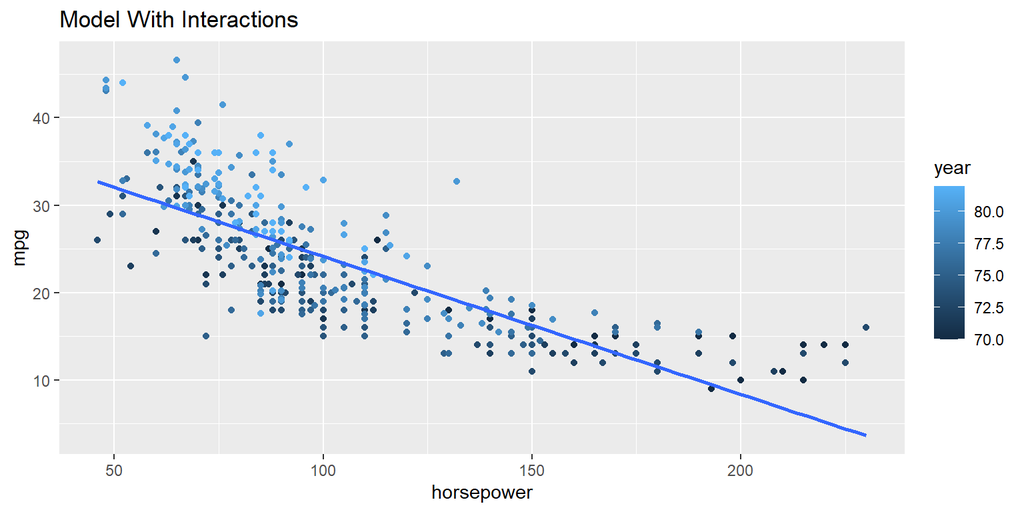

   ```r
   fit1.with.interaction <- lm(mpg ~ horsepower * year, data1)

   ggplot(Auto, aes(x=horsepower, y=mpg, color=year))+
     geom_point()+
     geom_smooth(method='lm', se=F, fill=NA)+
     labs(title = 'Model With Interactions')
   ```

```r
summary(fit1.with.interaction)
```

```
##
## Call:
## lm(formula = mpg ~ horsepower * year, data = data1)
##
## Residuals:
##     Min      1Q  Median      3Q     Max
## -12.349  -2.451  -0.456   2.406  14.444
##
## Coefficients:
##                  Estimate Std. Error t value Pr(>|t|)
## (Intercept)     -1.27e+02   1.21e+01  -10.45   <2e-16 ***
## horsepower       1.05e+00   1.15e-01    9.06   <2e-16 ***
## year             2.19e+00   1.61e-01   13.59   <2e-16 ***
## horsepower:year -1.60e-02   1.56e-03  -10.22   <2e-16 ***
## ---
## Signif. codes:  0 '***' 0.001 '**' 0.01 '*' 0.05 '.' 0.1 ' ' 1
##
## Residual standard error: 3.9 on 388 degrees of freedom
## Multiple R-squared:  0.752,  Adjusted R-squared:  0.75
## F-statistic:  393 on 3 and 388 DF,  p-value: <2e-16
```

To test whether the interaction effect is significant, we will first assume that there is no interaction effect.

```r
fit1.no.interaction <- lm(mpg ~ horsepower + year, data1)
anova(fit1.no.interaction, fit1.with.interaction)
```

```
## Analysis of Variance Table
##
## Model 1: mpg ~ horsepower + year
## Model 2: mpg ~ horsepower * year
##   Res.Df  RSS Df Sum of Sq   F Pr(>F)
## 1    389 7491
## 2    388 5903  1      1588 104 <2e-16 ***
## ---
## Signif. codes:  0 '***' 0.001 '**' 0.01 '*' 0.05 '.' 0.1 ' ' 1
```

```r
library('car')
Anova(fit1.with.interaction)
```

```
## Anova Table (Type II tests)
##
## Response: mpg
##                 Sum Sq  Df F value Pr(>F)
## horsepower        8300   1     546 <2e-16 ***
## year              1895   1     125 <2e-16 ***
## horsepower:year   1588   1     104 <2e-16 ***
## Residuals         5903 388
## ---
## Signif. codes:  0 '***' 0.001 '**' 0.01 '*' 0.05 '.' 0.1 ' ' 1
```

## 3.3 Categorical predictors

Remember that the same variable can play different roles! Take a quick look at the variable `cylinders`, and try to use this variable in the following analyses wisely. We all agree that a larger number of cylinders will lower mpg. However, we can interpret `cylinders` as either a continuous (numeric) variable or a categorical variable.

1. Fit a model that treats `cylinders` as a continuous/numeric variable. Is `cylinders` significant at the 0.01 level? What effect does `cylinders` play in this model?

   ```r
   fit.numeric.all <- lm(mpg ~., data1)
   Anova(fit.numeric.all)
   ```

   ```
   ## Note: model has aliased coefficients
   ##       sums of squares computed by model comparison
   ```

   ```
   ## Anova Table (Type II tests)
   ##
   ## Response: mpg
   ##              Sum Sq  Df F value  Pr(>F)
   ## cylinders        11   1    2.22 0.14023
   ## displacement      0   1    0.04 0.84611
   ## horsepower       11   1    2.12 0.14892
   ## weight           62   1   12.02 0.00083 ***
   ## acceleration     41   1    7.88 0.00621 **
   ## year            166   1   32.18 1.9e-07 ***
   ## origin                0
   ## name           3813 299    2.47 1.2e-06 ***
   ## Residuals       439  85
   ## ---
   ## Signif. codes:  0 '***' 0.001 '**' 0.01 '*' 0.05 '.' 0.1 ' ' 1
   ```

   ```r
   data3 <- select(data1, -name)
   data3$cylinders <- factor(data3$cylinders, levels = c("3", "4", "5", "6", "8"))
   ```

   ```r
   data3 %>%
   group_by(cylinders) %>%
     summarise(
       mean = mean(mpg),
       n = n()
     )
   ```

   ```
   ## # A tibble: 5 × 3
   ##   cylinders  mean     n
   ##   <fct>     <dbl> <int>
   ## 1 3          20.6     4
   ## 2 4          29.3   199
   ## 3 5          27.4     3
   ## 4 6          20.0    83
   ## 5 8          15.0   103
   ```

   ```r
   t.test(as.numeric(data3$cylinders),mu=2)
   ```

   ```
   ##
   ##  One Sample t-test
   ##
   ## data:  as.numeric(data3$cylinders)
   ## t = 18, df = 391, p-value <2e-16
   ## alternative hypothesis: true mean is not equal to 2
   ## 95 percent confidence interval:
   ##  3.08 3.34
   ## sample estimates:
   ## mean of x
   ##      3.21
   ```

   The mean of mpg for cylinders=4 is highest.

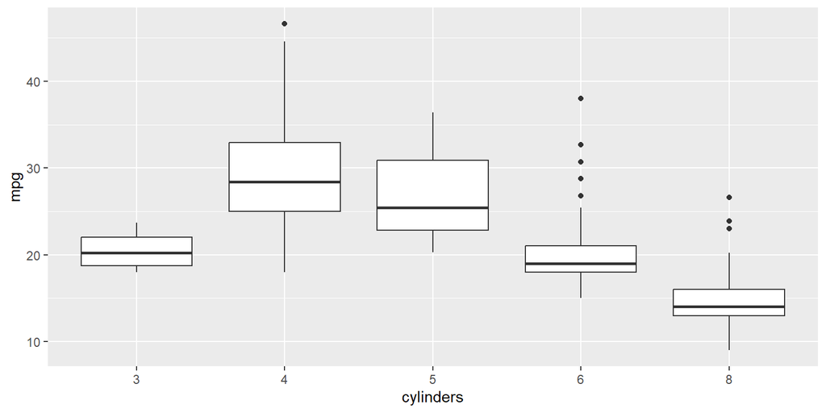

```r
ggplot(data3) + geom_boxplot(aes(x = cylinders, y = mpg))
```

```r
fit.categorical <- lm(mpg ~ cylinders, data3)
summary(fit.categorical)
```

```
##
## Call:
## lm(formula = mpg ~ cylinders, data = data3)
##
## Residuals:
##     Min      1Q  Median      3Q     Max
## -11.284  -2.904  -0.963   2.344  18.027
##
## Coefficients:
##             Estimate Std. Error t value Pr(>|t|)
## (Intercept)   20.550      2.349    8.75  < 2e-16 ***
## cylinders4     8.734      2.373    3.68  0.00027 ***
## cylinders5     6.817      3.589    1.90  0.05825 .
## cylinders6    -0.577      2.405   -0.24  0.81071
## cylinders8    -5.587      2.395   -2.33  0.02015 *
## ---
## Signif. codes:  0 '***' 0.001 '**' 0.01 '*' 0.05 '.' 0.1 ' ' 1
##
## Residual standard error: 4.7 on 387 degrees of freedom
## Multiple R-squared:  0.641,  Adjusted R-squared:  0.638
## F-statistic:  173 on 4 and 387 DF,  p-value: <2e-16
```

```r
confint(fit.categorical)
```

```
##               2.5 % 97.5 %
## (Intercept)  15.931 25.169
## cylinders4    4.069 13.399
## cylinders5   -0.239 13.873
## cylinders6   -5.306  4.153
## cylinders8  -10.295 -0.879
```

[output not shown]

```r
data3$cylinders <- factor(data3$cylinders, levels = c("4","3", "5", "6", "8"))
data3 %>%
  group_by(cylinders) %>%
  summarise(
    mean = mean(mpg),
    n = n()
  )
```

```
## # A tibble: 5 × 3
##   cylinders  mean     n
##   <fct>     <dbl> <int>
## 1 4          29.3   199
## 2 3          20.6     4
## 3 5          27.4     3
## 4 6          20.0    83
## 5 8          15.0   103
```

```r
fit.categorical <-  lm(mpg ~ cylinders+horsepower+weight+year+acceleration+displacement, data3)
summary(fit.categorical)
```

```
##
## Call:
## lm(formula = mpg ~ cylinders + horsepower + weight + year + acceleration +
##     displacement, data = data3)
##
## Residuals:
##    Min     1Q Median     3Q    Max
## -8.761 -2.029 -0.088  1.791 13.799
##
## Coefficients:
##               Estimate Std. Error t value Pr(>|t|)
## (Intercept)  -1.25e+01   4.39e+00   -2.86  0.00447 **
## cylinders3   -6.22e+00   1.68e+00   -3.71  0.00024 ***
## cylinders5    1.21e+00   1.90e+00    0.64  0.52332
## cylinders6   -3.35e+00   7.13e-01   -4.69  3.8e-06 ***
## cylinders8   -8.51e-01   1.25e+00   -0.68  0.49785
## horsepower   -2.24e-02   1.34e-02   -1.68  0.09449 .
## weight       -5.99e-03   6.38e-04   -9.38  < 2e-16 ***
## year          7.28e-01   4.90e-02   14.85  < 2e-16 ***
## acceleration  3.63e-02   9.58e-02    0.38  0.70489
## displacement  6.68e-03   6.91e-03    0.97  0.33446
## ---
## Signif. codes:  0 '***' 0.001 '**' 0.01 '*' 0.05 '.' 0.1 ' ' 1
##
## Residual standard error: 3.19 on 382 degrees of freedom
## Multiple R-squared:  0.837,  Adjusted R-squared:  0.833
## F-statistic:  217 on 9 and 382 DF,  p-value: <2e-16
```

3. What are the fundamental differences between treating `cylinders` as a continuous and categorical variable in your models?

   One difference is that when we treat them as continuous, we assume that continuous values of cylinders, such as 1, 1.5, 2.5, 3.5, are possible. However in the real world cars mostly have 4, 5, 6, or 8 cylinders. Therefore, whether one choose to treat variables as continuous vs categorical needs to take into account how the variable in interpreted in the real world and what values the variable could have. In this case, it makes more sense to treat cylinders categorically.
4. Can you test the null hypothesis: fit0: `mpg` is linear in `cylinders` vs. fit1: `mpg` relates to `cylinders` as a categorical variable at .01 level?

```r
unique(data3)
```

[output not shown]

[output cut: 378 more lines]

```r
fit.categorical <-  lm(mpg ~ cylinders+horsepower+weight+year+acceleration+displacement, data3)
```

```r
anova(fit.numeric.all, fit.categorical)
```

```
## Analysis of Variance Table
##
## Model 1: mpg ~ cylinders + displacement + horsepower + weight + acceleration +
##     year + origin + name
## Model 2: mpg ~ cylinders + horsepower + weight + year + acceleration +
##     displacement
##   Res.Df  RSS   Df Sum of Sq    F  Pr(>F)
## 1     85  439
## 2    382 3890 -297     -3452 2.25 9.8e-06 ***
## ---
## Signif. codes:  0 '***' 0.001 '**' 0.01 '*' 0.05 '.' 0.1 ' ' 1
```

## 3.4 Results

Final modeling question: we want to explore the effects of each feature as best as possible. You may explore interactions, feature transformations, higher order terms, or other strategies within reason. The model(s) should be as parsimonious (simple) as possible unless the gain in accuracy is significant from your point of view.

1. Describe the final model. Include diagnostic plots with particular focus on the model residuals and diagnoses.

   ```r
   unique(data3$cylinders)
   ```

   ```
   ## [1] 8 4 6 3 5
   ## Levels: 4 3 5 6 8
   ```

   ```r
   #change back to 3 cylinders as base
   data3$cylinders <- factor(data3$cylinders, levels = c("3", "4","5", "6", "8"))
   summary(lm(mpg ~ ., data3))
   ```

   ```
   ##
   ## Call:
   ## lm(formula = mpg ~ ., data = data3)
   ##
   ## Residuals:
   ##    Min     1Q Median     3Q    Max
   ## -8.795 -1.939 -0.075  1.655 12.659
   ##
   ## Coefficients:
   ##               Estimate Std. Error t value Pr(>|t|)
   ## (Intercept)  -2.27e+01   4.52e+00   -5.02  7.9e-07 ***
   ## cylinders4    6.95e+00   1.64e+00    4.25  2.7e-05 ***
   ## cylinders5    7.62e+00   2.45e+00    3.11    0.002 **
   ## cylinders6    3.52e+00   1.82e+00    1.94    0.053 .
   ## cylinders8    5.32e+00   2.10e+00    2.54    0.012 *
   ## displacement  1.72e-02   7.03e-03    2.44    0.015 *
   ## horsepower   -3.47e-02   1.32e-02   -2.62    0.009 **
   ## weight       -5.68e-03   6.23e-04   -9.12  < 2e-16 ***
   ## acceleration  2.44e-02   9.30e-02    0.26    0.793
   ## year          7.26e-01   4.76e-02   15.27  < 2e-16 ***
   ## origin        1.31e+00   2.64e-01    4.95  1.1e-06 ***
   ## ---
   ## Signif. codes:  0 '***' 0.001 '**' 0.01 '*' 0.05 '.' 0.1 ' ' 1
   ##
   ## Residual standard error: 3.1 on 381 degrees of freedom
   ## Multiple R-squared:  0.847,  Adjusted R-squared:  0.843
   ## F-statistic:  210 on 10 and 381 DF,  p-value: <2e-16
   ```

   ```r
   fit.all <- lm(mpg ~., data3)
   Anova(fit.all)
   ```

   ```
   ## Anova Table (Type II tests)
   ##
   ## Response: mpg
   ##              Sum Sq  Df F value  Pr(>F)
   ## cylinders       623   4   16.24 2.7e-12 ***
   ## displacement     57   1    5.95   0.015 *
   ## horsepower       66   1    6.89   0.009 **
   ## weight          799   1   83.25 < 2e-16 ***
   ## acceleration      1   1    0.07   0.793
   ## year           2236   1  233.06 < 2e-16 ***
   ## origin          235   1   24.54 1.1e-06 ***
   ## Residuals      3655 381
   ## ---
   ## Signif. codes:  0 '***' 0.001 '**' 0.01 '*' 0.05 '.' 0.1 ' ' 1
   ```

   When accounting for all variables, number of cylinders is still significant at 0.01 level, with p-value=2.7e-12. We notice that displacement and acceleration is not significant on 0.01 level.

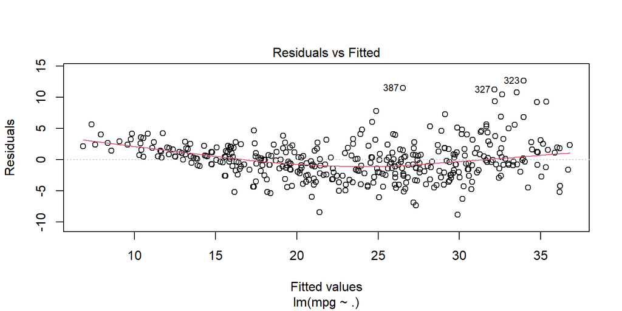

   ```r
   plot(fit.all, 1)
   ```

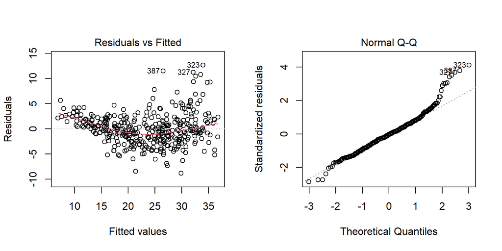

```r
par(mfrow=c(1,2))
plot(fit.all, 1)
plot(fit.all, 2)
```

We will use sandwich standard errors for a more accurate inferences over coefficients.

````
```r
#install.packages('sandwich')
library(sandwich)
fit.all <- lm(mpg ~., data3)
fit.all.hc <- lmtest::coeftest(fit.all, df = Inf, vcov = vcovHC)
fit.all.hc
```

```
##
## z test of coefficients:
##
##               Estimate Std. Error z value Pr(>|z|)
## (Intercept)  -22.68596    4.39026   -5.17  2.4e-07 ***
## cylinders4     6.95108    1.27080    5.47  4.5e-08 ***
## cylinders5     7.62312    5.34702    1.43   0.1540
## cylinders6     3.52315    1.52323    2.31   0.0207 *
## cylinders8     5.31569    1.82086    2.92   0.0035 **
## displacement   0.01716    0.00771    2.23   0.0261 *
## horsepower    -0.03470    0.01361   -2.55   0.0108 *
## weight        -0.00568    0.00071   -8.01  1.2e-15 ***
## acceleration   0.02437    0.12308    0.20   0.8430
## year           0.72615    0.04796   15.14  < 2e-16 ***
## origin         1.30554    0.27256    4.79  1.7e-06 ***
## ---
## Signif. codes:  0 '***' 0.001 '**' 0.01 '*' 0.05 '.' 0.1 ' ' 1
```
````

2. Summarize the effects found.
3. Predict the `mpg` of the following car: A red car built in the US in 1983 that is 180 inches long, has eight cylinders, displaces 350 cu. inches, weighs 4000 pounds, and has a horsepower of 260. Also give a 95% CI for your prediction.

```r
newcar <-  data3[1, ]  # Create a new row with same structure as in data1
newcar[1] <- "NA" # Assign features for the new car
newcar[2] <- as.factor("8")
newcar[3] <- 350.0
newcar["horsepower"] <- 260
newcar["weight"] <- 4000
data1["year"] <- 83
data1["origin"] <- 1

newcar
```

```
##   mpg cylinders displacement horsepower weight acceleration year origin
## 1  NA         8          350        260   4000           12   70      1
```

```r
fit.mean.new  <- predict(fit.all, newcar, interval = "confidence")
fit.mean.new
```

```
##    fit  lwr  upr
## 1 9.31 6.71 11.9
```

# 4 Case study 1: `ISLR::Auto` data

This will be the last part of the Auto data from ISLR. The original data contains 408 observations about cars. It has some similarity as the Cars data that we use in our lectures. To get the data, first install the package `ISLR`. The data set `Auto` should be loaded automatically. We use this case to go through methods learned so far.

```r
library(ISLR)
```

Final modelling question: We want to explore the effects of each feature as best as possible.

1. Preparing variables:
1. You may explore the possibility of variable transformations. We normally do not suggest to transform $x$ for the purpose of interpretation. You may consider to transform $y$ to either correct the violation of the linear model assumptions or if you feel a transformation of $y$ makes more sense from some theory. In this case we suggest you to look into `GPM=1/MPG`. Compare residual plots of MPG or GPM as responses and see which one might yield a more satisfactory patterns.

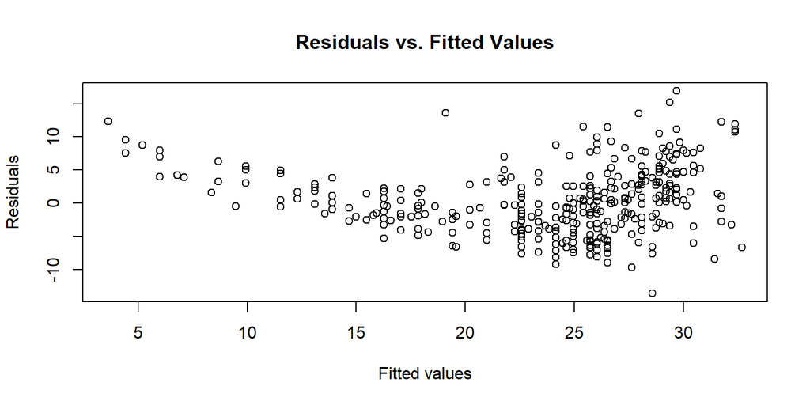

```r
library(ISLR)
data(Auto)

# lm MPG on horsepower
model <- lm(mpg ~ horsepower, data = Auto)

# residual plot
plot(model$fitted.values, model$residuals, xlab = "Fitted values", ylab = "Residuals",
     main = "Residuals vs. Fitted Values")
```

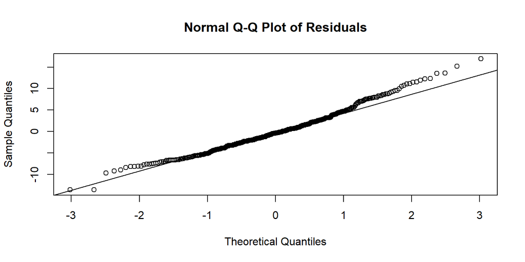

```r
# qqplot
qqnorm(model$residuals, main = "Normal Q-Q Plot of Residuals")
qqline(model$residuals)
```

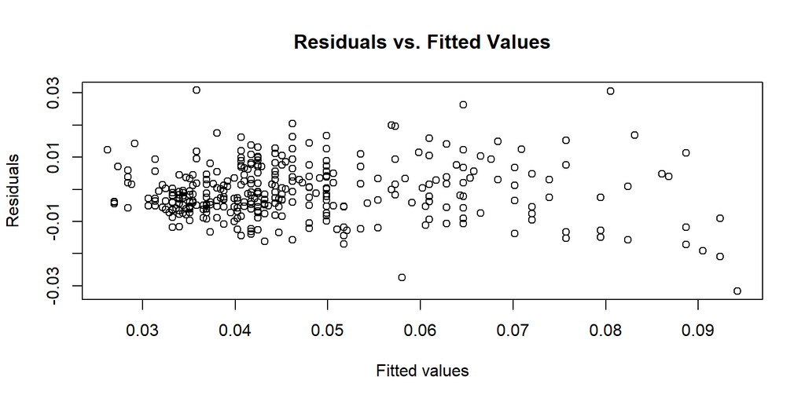

```r
# add gpm
Auto$GPM <- 1 / Auto$mpg

# lm for gpm on horsepower
model <- lm(GPM ~ horsepower, data = Auto)

# residual plot
plot(model$fitted.values, model$residuals, xlab = "Fitted values", ylab = "Residuals",
     main = "Residuals vs. Fitted Values")
```

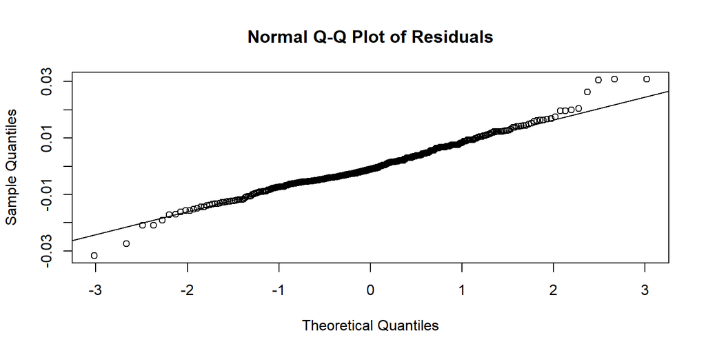

```r
# qqplot
qqnorm(model$residuals, main = "Normal Q-Q Plot of Residuals")
qqline(model$residuals)
```

In addition, can you provide some background knowledge to support the notion: it makes more sense to model `GPM`?

The Q-Q plot of residuals for GPM is closer to normal, which implies that it may be a better choice. Intuitively, it makes more sense to model GPM as this is a useful metric when purchasing a car, as it is a better gauge of fuel consumption, fuel savings, and between-car comparisons.

2. You may also explore by adding interactions and higher order terms. The model(s) should be as *parsimonious* (simple) as possible, unless the gain in accuracy is significant from your point of view.

```r
names(Auto)
```

```
##  [1] "mpg"          "cylinders"    "displacement" "horsepower"   "weight"
##  [6] "acceleration" "year"         "origin"       "name"         "GPM"
```

```r
fit.all <- lm(GPM ~., data=Auto)
summary(fit.all)
```

```
##
## Call:
## lm(formula = GPM ~ ., data = Auto)
##
## Residuals:
##      Min       1Q   Median       3Q      Max
## -0.00566  0.00000  0.00000  0.00000  0.00626
##
## Coefficients: (1 not defined because of singularities)
##                                           Estimate Std. Error t value Pr(>|t|)
## (Intercept)                               9.93e-02   1.56e-02    6.37  9.5e-09
## mpg                                      -1.60e-03   1.32e-04  -12.11  < 2e-16
## cylinders                                -2.39e-06   7.62e-04    0.00  0.99751
## displacement                              8.17e-05   1.91e-05    4.29  4.8e-05
## horsepower                               -9.77e-05   3.59e-05   -2.72  0.00788
## weight                                    1.14e-06   1.58e-06    0.72  0.47258
## acceleration                              7.58e-05   2.19e-04    0.35  0.72976
## year                                     -2.63e-04   1.61e-04   -1.64  0.10535
## origin                                    1.98e-04   5.18e-03    0.04  0.96962
## nameamc ambassador dpl                   -8.67e-03   3.98e-03   -2.18  0.03232
## nameamc ambassador sst                   -9.69e-03   4.01e-03   -2.41  0.01799
## nameamc concord                          -9.12e-03   3.99e-03   -2.28  0.02492
## nameamc concord d/l                      -9.07e-03   4.18e-03   -2.17  0.03283
## nameamc concord dl 6                     -1.21e-02   4.29e-03   -2.81  0.00609
## nameamc gremlin                          -1.08e-02   3.61e-03   -2.98  0.00376
## nameamc hornet                           -1.05e-02   3.54e-03   -2.96  0.00396
## nameamc hornet sportabout (sw)           -1.11e-02   4.30e-03   -2.58  0.01152
## nameamc matador                          -6.73e-03   3.25e-03   -2.07  0.04178
## nameamc matador (sw)                     -3.85e-03   3.55e-03   -1.08  0.28138
## nameamc pacer                            -1.18e-02   4.29e-03   -2.74  0.00751
## nameamc pacer d/l                        -1.11e-02   4.30e-03   -2.58  0.01173
## nameamc rebel sst                        -7.90e-03   4.02e-03   -1.96  0.05275
## nameamc spirit dl                        -4.52e-03   4.96e-03   -0.91  0.36399
## nameaudi 100 ls                          -4.94e-03   4.21e-03   -1.17  0.24422
## nameaudi 100ls                           -3.37e-03   3.66e-03   -0.92  0.35981
## nameaudi 4000                             1.51e-03   3.99e-03    0.38  0.70614
## nameaudi 5000                            -2.42e-03   4.24e-03   -0.57  0.57067
## nameaudi 5000s (diesel)                  -1.02e-03   4.53e-03   -0.22  0.82285
## nameaudi fox                             -2.91e-03   4.08e-03   -0.71  0.47722
## namebmw 2002                             -3.46e-03   4.19e-03   -0.82  0.41181
```

[output cut: 580 more lines]

```
## namevolvo 244dl
## namevolvo 245
## namevolvo 264gl
## namevolvo diesel
## namevw dasher (diesel)
## namevw pickup
## namevw rabbit
## namevw rabbit c (diesel)                 .
## namevw rabbit custom
## ---
## Signif. codes:  0 '***' 0.001 '**' 0.01 '*' 0.05 '.' 0.1 ' ' 1
##
## Residual standard error: 0.00277 on 84 degrees of freedom
## Multiple R-squared:  0.994,  Adjusted R-squared:  0.972
## F-statistic: 45.7 on 307 and 84 DF,  p-value: <2e-16
```

```r
aov(fit.all)
```

```
## Call:
##    aov(formula = fit.all)
##
## Terms:
##                    mpg cylinders displacement horsepower weight acceleration
## Sum of Squares  0.0948    0.0034       0.0006     0.0010 0.0003       0.0003
## Deg. of Freedom      1         1            1          1      1            1
##                   year origin   name Residuals
## Sum of Squares  0.0006 0.0000 0.0066    0.0006
## Deg. of Freedom      1      1    299        84
##
## Residual standard error: 0.00277
## 1 out of 309 effects not estimable
## Estimated effects may be unbalanced
```

```r
fit.no.interaction <- lm(GPM ~ cylinders + horsepower + weight + acceleration + year, data = Auto)
summary(fit.no.interaction)
```

```
##
## Call:
## lm(formula = GPM ~ cylinders + horsepower + weight + acceleration +
##     year, data = Auto)
##
## Residuals:
##       Min        1Q    Median        3Q       Max
## -0.015939 -0.003298 -0.000139  0.002837  0.024819
##
## Coefficients:
##               Estimate Std. Error t value Pr(>|t|)
## (Intercept)   9.08e-02   7.88e-03   11.52   <2e-16 ***
## cylinders     8.77e-04   4.11e-04    2.14    0.033 *
## horsepower    1.06e-04   2.24e-05    4.74    3e-06 ***
## weight        1.04e-05   1.00e-06   10.39   <2e-16 ***
## acceleration  3.65e-04   1.69e-04    2.16    0.031 *
## year         -1.26e-03   8.74e-05  -14.38   <2e-16 ***
## ---
## Signif. codes:  0 '***' 0.001 '**' 0.01 '*' 0.05 '.' 0.1 ' ' 1
##
## Residual standard error: 0.00572 on 386 degrees of freedom
## Multiple R-squared:  0.883,  Adjusted R-squared:  0.882
## F-statistic:  584 on 5 and 386 DF,  p-value: <2e-16
```

```r
fit.with.interaction <- lm(GPM ~ cylinders*horsepower*weight*acceleration + year, data = Auto)
summary(fit.with.interaction)
```

```
##
## Call:
## lm(formula = GPM ~ cylinders * horsepower * weight * acceleration +
##     year, data = Auto)
##
## Residuals:
##       Min        1Q    Median        3Q       Max
## -0.014456 -0.003085 -0.000336  0.002540  0.023157
##
## Coefficients:
##                                           Estimate Std. Error t value Pr(>|t|)
## (Intercept)                               3.64e-01   1.58e-01    2.30   0.0222
## cylinders                                -7.08e-02   2.74e-02   -2.58   0.0101
## horsepower                               -1.56e-03   1.77e-03   -0.88   0.3780
## weight                                   -4.20e-05   5.92e-05   -0.71   0.4778
## acceleration                             -1.85e-02   9.53e-03   -1.95   0.0524
## year                                     -1.24e-03   8.65e-05  -14.32   <2e-16
## cylinders:horsepower                      4.84e-04   2.51e-04    1.93   0.0542
## cylinders:weight                          1.74e-05   9.01e-06    1.93   0.0547
## horsepower:weight                         1.73e-07   6.78e-07    0.25   0.7991
## cylinders:acceleration                    5.31e-03   1.77e-03    3.00   0.0029
## horsepower:acceleration                   9.99e-05   1.07e-04    0.93   0.3513
## weight:acceleration                       3.60e-06   3.48e-06    1.03   0.3020
## cylinders:horsepower:weight              -1.01e-07   8.97e-08   -1.13   0.2591
## cylinders:horsepower:acceleration        -3.41e-05   1.61e-05   -2.11   0.0351
## cylinders:weight:acceleration            -1.32e-06   5.58e-07   -2.36   0.0187
## horsepower:weight:acceleration           -6.22e-09   4.04e-08   -0.15   0.8776
## cylinders:horsepower:weight:acceleration  7.17e-09   5.46e-09    1.31   0.1901
##
## (Intercept)                              *
## cylinders                                *
## horsepower
## weight
## acceleration                             .
## year                                     ***
## cylinders:horsepower                     .
## cylinders:weight                         .
## horsepower:weight
## cylinders:acceleration                   **
## horsepower:acceleration
## weight:acceleration
## cylinders:horsepower:weight
## cylinders:horsepower:acceleration        *
## cylinders:weight:acceleration            *
## horsepower:weight:acceleration
## cylinders:horsepower:weight:acceleration
## ---
## Signif. codes:  0 '***' 0.001 '**' 0.01 '*' 0.05 '.' 0.1 ' ' 1
##
## Residual standard error: 0.00529 on 375 degrees of freedom
## Multiple R-squared:  0.903,  Adjusted R-squared:  0.899
## F-statistic:  218 on 16 and 375 DF,  p-value: <2e-16
```

```r
anova(fit.no.interaction, fit.with.interaction)
```

```
## Analysis of Variance Table
##
## Model 1: GPM ~ cylinders + horsepower + weight + acceleration + year
## Model 2: GPM ~ cylinders * horsepower * weight * acceleration + year
##   Res.Df    RSS Df Sum of Sq    F  Pr(>F)
## 1    386 0.0126
## 2    375 0.0105 11   0.00213 6.93 1.1e-10 ***
## ---
## Signif. codes:  0 '***' 0.001 '**' 0.01 '*' 0.05 '.' 0.1 ' ' 1
```

In exploring different multiple regressions, we varied including and excluding interaction, as well as different combinations of terms that would reasonably interact with one another. The initial model with no interaction already has a very high R^2 value. Running an anova between the models with and without interaction reveals that because the p-value is low enough to reject the null, there must be some interaction between cylinder count, horsepower, weight, and acceleration.

3. Use Mallow’s $C_p$ or BIC to select the model.

```r
library(leaps)
names(Auto)
```

```
##  [1] "mpg"          "cylinders"    "displacement" "horsepower"   "weight"
##  [6] "acceleration" "year"         "origin"       "name"         "GPM"
```

```r
selected_columns <- Auto[, c("cylinders", "displacement", "horsepower", "weight", "acceleration", "year", "origin", "GPM")]
fit.exh <- regsubsets(GPM ~., selected_columns , nvmax = 10,  method="exhaustive", )
f.e <- summary(fit.exh)
f.e$which
```

```
##   (Intercept) cylinders displacement horsepower weight acceleration  year
## 1        TRUE     FALSE        FALSE      FALSE   TRUE        FALSE FALSE
## 2        TRUE     FALSE        FALSE      FALSE   TRUE        FALSE  TRUE
## 3        TRUE     FALSE        FALSE       TRUE   TRUE        FALSE  TRUE
## 4        TRUE     FALSE        FALSE       TRUE   TRUE         TRUE  TRUE
## 5        TRUE      TRUE        FALSE       TRUE   TRUE         TRUE  TRUE
## 6        TRUE      TRUE        FALSE       TRUE   TRUE         TRUE  TRUE
## 7        TRUE      TRUE         TRUE       TRUE   TRUE         TRUE  TRUE
##   origin
## 1  FALSE
## 2  FALSE
## 3  FALSE
## 4  FALSE
## 5  FALSE
## 6   TRUE
## 7   TRUE
```

```r
f.e$cp
```

```
## [1] 337.1  39.3  14.5  13.1  10.5  10.0   8.0
```

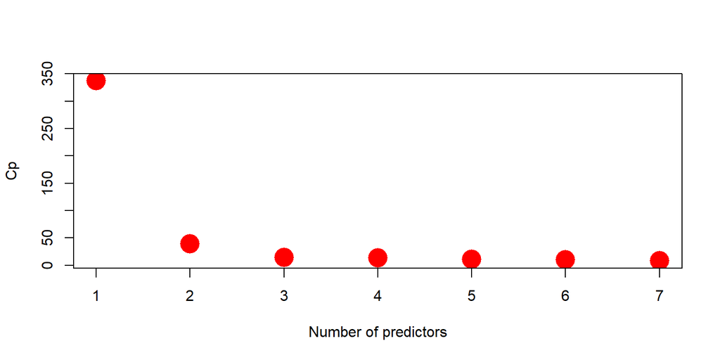

```r
plot(f.e$cp, xlab="Number of predictors",
     ylab="Cp", col="red", pch=16, cex =3)
```

```r
opt.size <- which.min(f.e$cp)
opt.size
```

```
## [1] 7
```

```r
coef(fit.exh, 7)
```

```
##  (Intercept)    cylinders displacement   horsepower       weight acceleration
##     9.14e-02     1.51e-03    -2.57e-05     1.26e-04     1.09e-05     3.42e-04
##         year       origin
##    -1.26e-03    -1.01e-03
```

```r
fit.final <- lm(GPM ~ cylinders + horsepower + weight + acceleration + year + origin + displacement, selected_columns)
summary(fit.final)
```

```
##
## Call:
## lm(formula = GPM ~ cylinders + horsepower + weight + acceleration +
##     year + origin + displacement, data = selected_columns)
##
## Residuals:
##       Min        1Q    Median        3Q       Max
## -0.016017 -0.003348 -0.000111  0.002933  0.023540
##
## Coefficients:
##               Estimate Std. Error t value Pr(>|t|)
## (Intercept)   9.14e-02   7.94e-03   11.52  < 2e-16 ***
## cylinders     1.51e-03   5.53e-04    2.73   0.0066 **
## horsepower    1.26e-04   2.36e-05    5.33  1.7e-07 ***
## weight        1.09e-05   1.11e-06    9.75  < 2e-16 ***
## acceleration  3.42e-04   1.69e-04    2.03   0.0435 *
## year         -1.26e-03   8.71e-05  -14.51  < 2e-16 ***
## origin       -1.01e-03   4.75e-04   -2.13   0.0339 *
## displacement -2.57e-05   1.28e-05   -2.00   0.0461 *
## ---
## Signif. codes:  0 '***' 0.001 '**' 0.01 '*' 0.05 '.' 0.1 ' ' 1
##
## Residual standard error: 0.00569 on 384 degrees of freedom
## Multiple R-squared:  0.885,  Adjusted R-squared:  0.883
## F-statistic:  423 on 7 and 384 DF,  p-value: <2e-16
```

2. Describe the final model and its accuracy. Include diagnostic plots with particular focus on the model residuals.

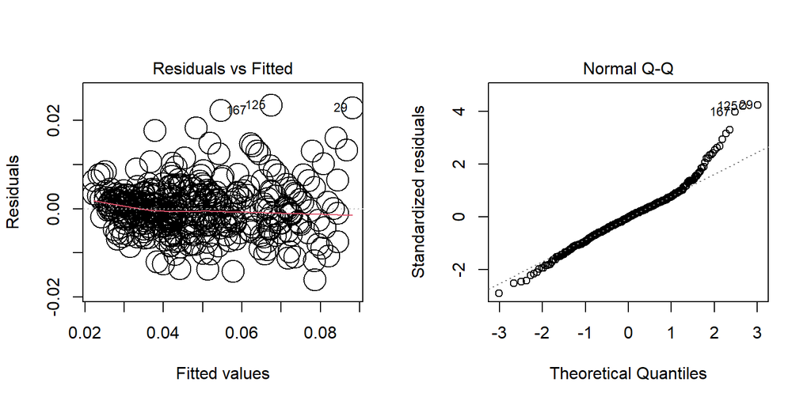

```r
par(mfrow=c(1,2))
plot(fit.final, 1, cex =3)  # max(fit.final$res) = 3;
plot(fit.final, 2)
```

- Summarize the effects found.
- Predict the `mpg` of a car that is: built in 1983, in the US, red, 180 inches long, 8 cylinders, 350 displacement, 260 as horsepower, and weighs 4,000 pounds. Give a 95% CI.

```r
car <- selected_columns [1,]
car[1] <- NA
car$cylinders <- 8
car$displacement <- 350
car$horsepower <- 260
car$weight <- 4000
car$year <- 1983

car.m <- predict(fit.final, car, interval="confidence", se.fit=TRUE)
car.m  # in log scale
```

```
## $fit
##     fit   lwr upr
## 1 -2.33 -2.66  -2
##
## $se.fit
## [1] 0.167
##
## $df
## [1] 384
##
## $residual.scale
## [1] 0.00569
```

```r
exp(car.m$fit)
```

```
##     fit    lwr   upr
## 1 0.097 0.0699 0.135
```

- Any suggestions as to how to improve the quality of the study?

To improve the quality of the study, we would look to expand the types of data collected in the original Auto data set. Including more variables would allow us to better predict prices based on features.

# 5 Case study 2: COVID19

# 6 Background

The outbreak of the novel Corona virus disease 2019 (COVID-19) was declared a public health emergency of international concern by the World Health Organization (WHO) on January 30, 2020. Upwards of [755 million cases have been confirmed worldwide, with nearly 6.8 million associated deaths](https://covid19.who.int/) by Feb of 2023. Within the US alone, there have been [over 1.1 million deaths and upwards of 102 million cases reported](https://covid.cdc.gov/covid-data-tracker/#trends_dailytrendscases) by Feb of 2023. Governments around the world have implemented and suggested a number of policies to lessen the spread of the pandemic, including mask-wearing requirements, travel restrictions, business and school closures, and even stay-at-home orders. The global pandemic has impacted the lives of individuals in countless ways, and though many countries have begun vaccinating individuals, the long-term impact of the virus remains unclear.

The impact of COVID-19 on a given segment of the population appears to vary drastically based on the socioeconomic characteristics of the segment. In particular, differing rates of infection and fatalities have been reported among different [racial groups](https://www.cdc.gov/coronavirus/2019-ncov/covid-data/investigations-discovery/hospitalization-death-by-race-ethnicity.html), [age groups](https://www.cdc.gov/coronavirus/2019-ncov/covid-data/investigations-discovery/hospitalization-death-by-age.html), and [socioeconomic groups](https://www.ncbi.nlm.nih.gov/pmc/articles/PMC7221360/). One of the most important metrics for determining the impact of the pandemic is the death rate, which is the proportion of people within the total population that die due to the the disease.

We assemble this dataset for our research with the goal to investigate the effectiveness of lockdown on flattening the COVID curve. We provide a portion of the cleaned dataset for this case study.

There are two main goals for this case study.

1. We show the dynamic evolvement of COVID cases and COVID-related death at state level.
2. We try to figure out what county-level demographic and policy interventions are associated with mortality rate in the US. We try to construct models to find possible factors related to county-level COVID-19 mortality rates.
3. This is a rather complex project. With our team’s help we have made your job easier.
4. Hide all unnecessary lengthy R-output. Keep your write up neat, readable.

**Remark1:** The data and the statistics reported here were collected before February of 2021.

**Remark 2:** A group of RAs spent tremendous amount of time working together to assemble the data. It requires data wrangling skills.

**Remark 3:** Please keep track with the most updated version of this write-up.

# 7 Data Summary

The data comes from several different sources:

1. [County-level infection and fatality data](https://github.com/nytimes/covid-19-data) - This dataset gives daily cumulative numbers on infection and fatality for each county.
   - [NYC data](https://github.com/nychealth/coronavirus-data)
2. [County-level socioeconomic data](https://www.ers.usda.gov/data-products/atlas-of-rural-and-small-town-america/download-the-data/) - The following are the four relevant datasets from this site.
   1. Income - Poverty level and household income.
   2. Jobs - Employment type, rate, and change.
   3. People - Population size, density, education level, race, age, household size, and migration rates.
   4. County Classifications - Type of county (rural or urban on a rural-urban continuum scale).
3. [Intervention Policy Data](https://github.com/JieYingWu/COVID-19_US_County-level_Summaries/blob/master/data/interventions.csv) - This dataset is a manually compiled list of the dates that interventions/lockdown policies were implemented and lifted at the county level.

# 8 EDA

In this case study, we use the following three nearly cleaned data:

- **covid_county.csv**: County-level socialeconomic information that combines the above-mentioned 4 datasets: Income (Poverty level and household income), Jobs (Employment type, rate, and change), People (Population size, density, education level, race, age, household size, and migration rates), County Classifications
- **covid_rates.csv**: Daily cumulative numbers on infection and fatality for each county
- **covid_intervention.csv**: County-level lockdown intervention.

Among all data, the unique identifier of county is `FIPS`.

The cleaning procedure is attached in `Appendix 2: Data cleaning` You may go through it if you are interested or would like to make any changes.

**It may need more data wrangling.**

First read in the data.

```r
# county-level socialeconomic information
county_data <- fread("data/covid_county.csv")
# county-level COVID case and death
covid_rate <- fread("data/covid_rates.csv")
# county-level lockdown dates
 covid_intervention <- fread("data/covid_intervention.csv")
```

## 8.1 Understand the data

The detailed description of variables is in `Appendix 1: Data description`. Please get familiar with the variables. Summarize the two data briefly. ## Infection and fatality data

- date: Date
- county: County name
- state: State name
- fips: County code that uniquely identifies a county
- cases: Number of cumulative COVID-19 infections
- deaths: Number of cumulative COVID-19 deaths

## 8.2 COVID case trend

It is crucial to decide the right granularity for visualization and analysis. We will compare daily vs weekly total new cases by state and we will see it is hard to interpret daily report.

1. Plot **new** COVID cases in NY, WA and FL by state and by day. Any irregular pattern? What is the biggest problem of using single day data?

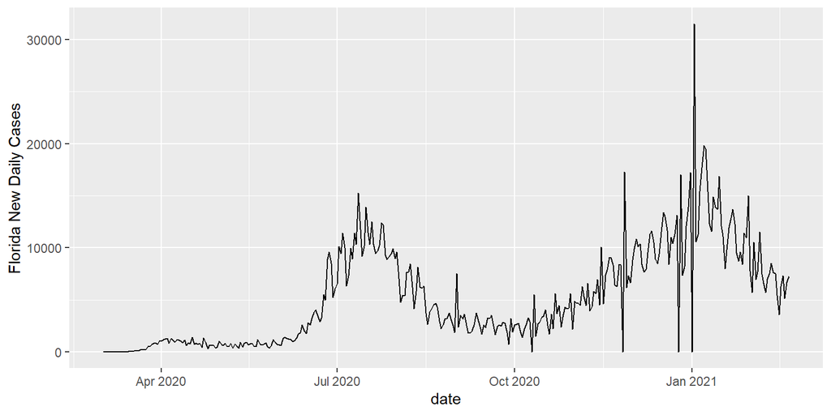

```r
fl_data <- covid_rate[covid_rate$State == "Florida"] %>%
  select(date, cum_cases)%>%
  group_by(date) %>%
  summarize(cum_cases = sum(cum_cases)) %>%
  mutate(new = cum_cases - lag(cum_cases))
fl_data <- fl_data %>% filter(!is.na(new))
wa_data <- covid_rate[covid_rate$State == "Washington"] %>%
  select(date, cum_cases)%>%
  group_by(date) %>%
  summarize(cum_cases = sum(cum_cases)) %>%
  mutate(new = cum_cases - lag(cum_cases))
wa_data <- wa_data %>% filter(!is.na(new))
ny_data <- covid_rate[covid_rate$State == "New York"] %>%
  select(date, cum_cases)%>%
  group_by(date) %>%
  summarize(cum_cases = sum(cum_cases)) %>%
  mutate(new = cum_cases - lag(cum_cases))
ny_data <- ny_data %>% filter(!is.na(new))

ggplot(fl_data,aes(x=date, y=new))+geom_line()+labs(y="Florida New Daily Cases")
```

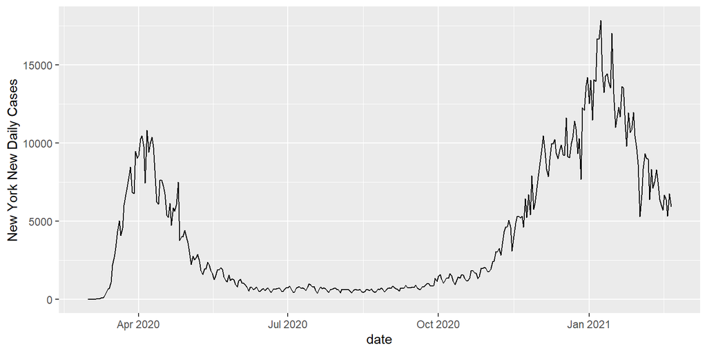

```r
ggplot(ny_data,aes(x=date, y=new))+geom_line()+labs(y="New York New Daily Cases")
```

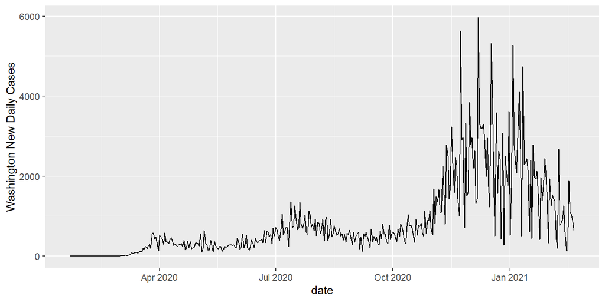

```r
ggplot(wa_data,aes(x=date, y=new))+geom_line()+labs(y="Washington New Daily Cases")
```

```r
ny_data
```

```
## # A tibble: 357 × 3
##    date       cum_cases   new
##    <IDate>        <int> <int>
##  1 2020-03-01         1     0
##  2 2020-03-02         1     0
##  3 2020-03-03         2     1
##  4 2020-03-04        16    14
##  5 2020-03-05        28    12
##  6 2020-03-06        57    29
##  7 2020-03-07       102    45
##  8 2020-03-08       138    36
##  9 2020-03-09       226    88
## 10 2020-03-10       309    83
## # … with 347 more rows
```

```r
covid_rate
```

```
##           FIPS       date  County       State cum_cases cum_deaths week
##       1: 10001 2020-03-18    Kent    Delaware         3          0    9
##       2: 10001 2020-03-19    Kent    Delaware         4          0    9
##       3: 10001 2020-03-20    Kent    Delaware         4          0    9
##       4: 10001 2020-03-21    Kent    Delaware         5          0    9
##       5: 10001 2020-03-22    Kent    Delaware         5          0   10
##      ---
## 1008980:  9015 2021-02-16 Windham Connecticut      8963        172   57
## 1008981:  9015 2021-02-17 Windham Connecticut      8974        174   57
## 1008982:  9015 2021-02-18 Windham Connecticut      8976        174   57
## 1008983:  9015 2021-02-19 Windham Connecticut      9028        176   57
## 1008984:  9015 2021-02-20 Windham Connecticut      9028        176   57
##          TotalPopEst2019
##       1:          180786
##       2:          180786
##       3:          180786
##       4:          180786
##       5:          180786
##      ---
## 1008980:          116782
## 1008981:          116782
## 1008982:          116782
## 1008983:          116782
## 1008984:          116782
```

The issue with single day data is it varies based on the day of the week. The weekends have fewer cases likely because not every hospital is processing cases/deaths, and it jumps up during the week. Because of this, the data is very noisy and a 7 day moving average may be more useful.

2. Create **weekly new** cases per 100k `weekly_case_per100k`. Plot the spagheti plots of `weekly_case_per100k` by state. Use `TotalPopEst2019` as population.

```r
weekly_state <- covid_rate %>%
  select(State, week, cum_cases, TotalPopEst2019) %>%
  group_by(week, State) %>%
  summarize(TotalPopEst2019 = mean(TotalPopEst2019), cum_cases = sum(cum_cases)) %>%
  mutate(new = cum_cases - lag(cum_cases))
```

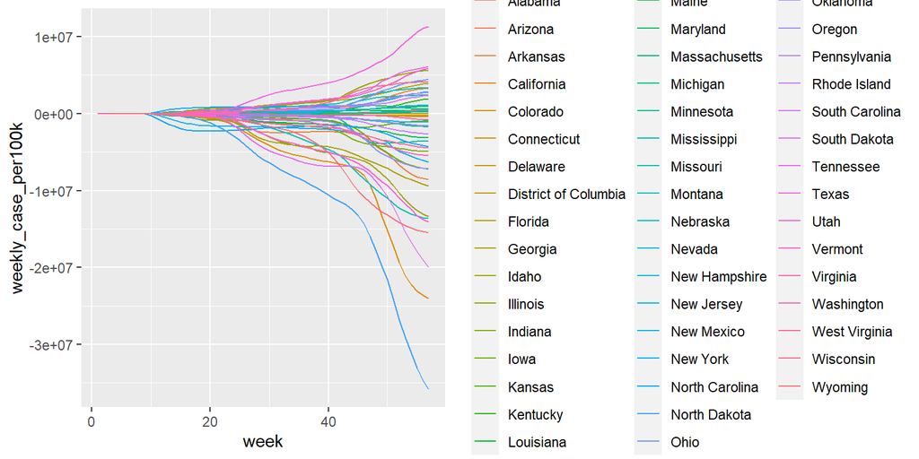

```r
weekly_state$weekly_case_per100k <- weekly_state$new/weekly_state$TotalPopEst2019*100000
p <- ggplot(data = weekly_state, aes(x = week, y = weekly_case_per100k, group = State, colour = State))
p + geom_line()
```

```r
#ggplot(fl_data,aes(x=date, y=new))+geom_line()+labs(y="Florida New Daily Cases")
weekly_state
```

```
## # A tibble: 2,518 × 6
## # Groups:   week [57]
##     week State         TotalPopEst2019 cum_cases   new weekly_case_per100k
##    <int> <chr>                   <dbl>     <int> <int>               <dbl>
##  1     1 California           3175692          1    NA             NA
##  2     1 Illinois             5150233          2     1              0.0194
##  3     1 Washington            822083          5     3              0.365
##  4     2 Arizona              4485414          7    NA             NA
##  5     2 California           6022456.        16     9              0.149
##  6     2 Illinois             5150233         10    -6             -0.116
##  7     2 Massachusetts         803907          1    -9             -1.12
##  8     2 Washington            822083          7     6              0.730
##  9     3 Arizona              4485414          7    NA             NA
## 10     3 California           4006050         42    35              0.874
## # … with 2,508 more rows
```

```r
covid_rate
```

```
##           FIPS       date  County       State cum_cases cum_deaths week
##       1: 10001 2020-03-18    Kent    Delaware         3          0    9
##       2: 10001 2020-03-19    Kent    Delaware         4          0    9
##       3: 10001 2020-03-20    Kent    Delaware         4          0    9
##       4: 10001 2020-03-21    Kent    Delaware         5          0    9
##       5: 10001 2020-03-22    Kent    Delaware         5          0   10
##      ---
## 1008980:  9015 2021-02-16 Windham Connecticut      8963        172   57
## 1008981:  9015 2021-02-17 Windham Connecticut      8974        174   57
## 1008982:  9015 2021-02-18 Windham Connecticut      8976        174   57
## 1008983:  9015 2021-02-19 Windham Connecticut      9028        176   57
## 1008984:  9015 2021-02-20 Windham Connecticut      9028        176   57
##          TotalPopEst2019
##       1:          180786
##       2:          180786
##       3:          180786
##       4:          180786
##       5:          180786
##      ---
## 1008980:          116782
## 1008981:          116782
## 1008982:          116782
## 1008983:          116782
## 1008984:          116782
```

The weekly trends vary wildly over time, with variability in rates increasing dramatically over time. This could be because of policies implemented that varied between states.

3. Summarize the COVID case trend among states based on the plot in ii). What could be the possible reasons to explain the variabilities?
4. (Optional) Use `covid_intervention` to see whether the effectiveness of lockdown in flattening the curve.

## 8.3 COVID death trend

1. For each month in 2020, plot the monthly deaths per 100k heatmap by state on US map. Use the same color range across months. (Hints: Set `limits` argument in `scale_fill_gradient()` or use `facet_wrap()`; use `lubridate::month()` and `lubridate::year()` to extract month and year from date; use `tidyr::complete(state, month, fill = list(new_case_per100k = NA))` to complete the missing months with no cases.)

```r
month_state <- copy(covid_rate)
month_state$year <- format(as.Date(covid_rate$date), "%Y")
month_state$month <- format(as.Date(covid_rate$date), "%m")

month_state[month_state$year == "2020",]
```

```
##          FIPS       date  County       State cum_cases cum_deaths week
##      1: 10001 2020-03-18    Kent    Delaware         3          0    9
##      2: 10001 2020-03-19    Kent    Delaware         4          0    9
##      3: 10001 2020-03-20    Kent    Delaware         4          0    9
##      4: 10001 2020-03-21    Kent    Delaware         5          0    9
##      5: 10001 2020-03-22    Kent    Delaware         5          0   10
##     ---
## 850472:  9015 2020-12-27 Windham Connecticut      4591         65   50
## 850473:  9015 2020-12-28 Windham Connecticut      4964         71   50
## 850474:  9015 2020-12-29 Windham Connecticut      4989         72   50
## 850475:  9015 2020-12-30 Windham Connecticut      5066         75   50
## 850476:  9015 2020-12-31 Windham Connecticut      5140         78   50
##         TotalPopEst2019 year month
##      1:          180786 2020    03
##      2:          180786 2020    03
##      3:          180786 2020    03
##      4:          180786 2020    03
##      5:          180786 2020    03
##     ---
## 850472:          116782 2020    12
## 850473:          116782 2020    12
## 850474:          116782 2020    12
## 850475:          116782 2020    12
## 850476:          116782 2020    12
```

```r
month_state <- month_state %>%
  select(State, month, cum_cases, TotalPopEst2019) %>%
  group_by(month, State) %>%
  summarize(TotalPopEst2019 = mean(TotalPopEst2019), cum_cases = sum(cum_cases)) %>%
  mutate(new = cum_cases - lag(cum_cases))
month_state$monthly_case_per100k <- month_state$new/month_state$TotalPopEst2019
month_state
```

```
## # A tibble: 588 × 6
## # Groups:   month [12]
##    month State                TotalPopEst2019 cum_cases       new monthly_case…¹
##    <chr> <chr>                          <dbl>     <int>     <int>          <dbl>
##  1 01    Alabama                       73182.  12918813        NA          NA
##  2 01    Arizona                      536205.  20456582   7537769          14.1
##  3 01    Arkansas                      40237.   8159627 -12296955        -306.
##  4 01    California                   722556.  90315290  82155663         114.
##  5 01    Colorado                      89980.  11537516 -78777774        -876.
##  6 01    Connecticut                  445661.   6876543  -4660973         -10.5
##  7 01    Delaware                     324588    2130534  -4746009         -14.6
##  8 01    District of Columbia         705749    1030286  -1100248          -1.56
##  9 01    Florida                      320563.  47786332  46756046         146.
## 10 01    Georgia                       66776.  23959182 -23827150        -357.
## # … with 578 more rows, and abbreviated variable name ¹monthly_case_per100k
```

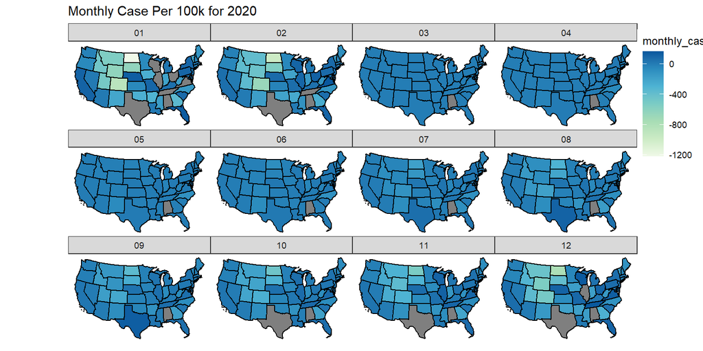

```r
library(usmap)
library(ggplot2)

max <- quantile(month_state$monthly_case_per100k, .98, na.rm = T)
min <- quantile(month_state$monthly_case_per100k, 0, na.rm = T)

#for (i in arr) {
toplot <-month_state
toplot$state <-toplot$State

stat.plot <- plot_usmap(regions = "state", data= toplot,values = "monthly_case_per100k", exclude = c("Hawaii", "Alaska"), color = "black") + facet_wrap(~month) + scale_fill_distiller(palette = "GnBu",
direction = 1,
# limits sets range of color
name = "monthly_case_per100k",
limits = c(min, max)) +
labs(title = "Monthly Case Per 100k for 2020") +
theme(legend.position = c(1,.6))
stat.plot
```

2. (Optional) Use `plotly` to animate the monthly maps in i). Does it reveal any systematic way to capture the dynamic changes among states? (Hints: Follow *Appendix 3: Plotly heatmap::* in Module 6 regularization lecture to plot the heatmap using `plotly`. Use `frame` argument in `add_trace()` for animation. `plotly` only recognizes abbreviation of state names. Use `unique(us_map(regions = "states") %>% select(abbr, full))` to get the abbreviation and merge with the data to get state abbreviation.)

# 9 COVID factor

We now try to build a good parsimonious model to find possible factors related to death rate on county level. Let us not take time series into account for the moment and use the total number as of *Feb 1, 2021*.

1. Create the response variable `total_death_per100k` as the total of number of COVID deaths per 100k by *Feb 1, 2021*. We suggest to take log transformation as `log_total_death_per100k = log(total_death_per100k + 1)`. Merge `total_death_per100k` to `county_data` for the following analysis.

```r
#county_data
county <- covid_rate %>%
  select(date, County, State, cum_deaths, TotalPopEst2019)%>%
  filter(date == '2021-02-01')
county$State <- state.abb[match(county$State,state.name)]
county
```

```
##             date     County State cum_deaths TotalPopEst2019
##    1: 2021-02-01       Kent    DE        203          180786
##    2: 2021-02-01 New Castle    DE        549          558753
##    3: 2021-02-01     Sussex    DE        349          234225
##    4: 2021-02-01    Autauga    AL         69           55869
##    5: 2021-02-01    Baldwin    AL        224          223234
##   ---
## 3104: 2021-02-01  Middlesex    CT        322          162436
## 3105: 2021-02-01  New Haven    CT       1803          854757
## 3106: 2021-02-01 New London    CT        368          265206
## 3107: 2021-02-01    Tolland    CT        140          150721
## 3108: 2021-02-01    Windham    CT        149          116782
```

```r
county_death <- county %>%
  inner_join(county_data, by = c("County", "State"))
county_death$log_total_death_per100k <- log((county_death$cum_deaths/county_death$TotalPopEst2019.x) +1)

#county_death
```

2. Select possible variables in `county_data` as covariates. We provide `county_data_sub`, a subset variables from `county_data`, for you to get started. Please add any potential variables as you wish.
   1. Report missing values in your final subset of variables.

   ```r
   na.omit(county_data)
   ```

   [output cut: 729 more lines]

   2. In the following anaylsis, you may ignore the missing values.

```r
county_data_sub <- county_data %>%
  select(County, State, FIPS, Deep_Pov_All, PovertyAllAgesPct, PerCapitaInc, UnempRate2019, PctEmpFIRE, PctEmpConstruction, PctEmpTrans, PctEmpMining, PctEmpTrade, PctEmpInformation, PctEmpAgriculture, PctEmpManufacturing, PctEmpServices, PopDensity2010, OwnHomePct, Age65AndOlderPct2010, TotalPop25Plus, Under18Pct2010, Ed2HSDiplomaOnlyPct, Ed3SomeCollegePct, Ed4AssocDegreePct, Ed5CollegePlusPct, ForeignBornPct, Net_International_Migration_Rate_2010_2019, NetMigrationRate1019, NaturalChangeRate1019, TotalPopEst2019, WhiteNonHispanicPct2010, NativeAmericanNonHispanicPct2010, BlackNonHispanicPct2010, AsianNonHispanicPct2010, HispanicPct2010, Type_2015_Update, RuralUrbanContinuumCode2013, UrbanInfluenceCode2013, Perpov_1980_0711, HiCreativeClass2000, HiAmenity, Retirement_Destination_2015_Update)
county_death <- county %>%
  inner_join(county_data_sub, by = c("County", "State"))
county_death$log_total_death_per100k <- log((county_death$cum_deaths/county_death$TotalPopEst2019.x) +1)
county_death <- na.omit(county_death)
county_death <- county_death %>%select(State, everything())
county_death
```

```
##       State       date     County cum_deaths TotalPopEst2019.x  FIPS
##    1:    DE 2021-02-01       Kent        203            180786 10001
##    2:    DE 2021-02-01 New Castle        549            558753 10003
##    3:    DE 2021-02-01     Sussex        349            234225 10005
##    4:    AL 2021-02-01    Autauga         69             55869  1001
##    5:    AL 2021-02-01    Baldwin        224            223234  1003
##   ---
## 3059:    CT 2021-02-01  Middlesex        322            162436  9007
## 3060:    CT 2021-02-01  New Haven       1803            854757  9009
## 3061:    CT 2021-02-01 New London        368            265206  9011
## 3062:    CT 2021-02-01    Tolland        140            150721  9013
## 3063:    CT 2021-02-01    Windham        149            116782  9015
##       Deep_Pov_All PovertyAllAgesPct PerCapitaInc UnempRate2019 PctEmpFIRE
##    1:         5.70              13.8        28100           4.2       5.49
##    2:         5.91              11.6        35847           3.7      12.17
```

[output cut: 141 more lines]

3. Use LASSO to choose a parsimonious model with all available sensible county-level information. **Force in State** in the process. Why we need to force in State? You may use `lambda.1se` to choose a smaller model.

We need to force in state because we are trying to predict death rate based on county-level information, and counties are situated in States. This makes the State that the county is located in very important so we need to make sure it is in the model.

```r
install.packages(c("glmnet", "faraway"), repos= "http://cran.us.r-project.org")
library(glmnet)
library(faraway)
county_death <- na.omit(county_death)
county_death <- subset(county_death, select = -County )
Y <- as.matrix(county_death$log_total_death_per100k) # extract Y
X <- model.matrix(log_total_death_per100k~., county_death)[,-1]
#X <- as.matrix(county_death[,1:45])
#X <- cbind(c(1), X)
dim(X)
```

```
## [1] 3063   90
```

```r
dim(Y)
```

```
## [1] 3063    1
```

```r
fit.deaths <- cv.glmnet(X, Y, alpha=1, penalty.factor = rep(c(0, 1),times=c(48, ncol(X)-48)))
fit.deaths$lambda.min
```

```
## [1] 4.2e-08
```

```r
fit.deaths$lambda.1se
```

```
## [1] 2.35e-05
```

```r
coef.1se <- coef(fit.deaths, s="lambda.1se")
coef.1se <- coef.1se[which(coef.1se !=0),]
var.min <- rownames(as.matrix(coef.1se))[-1]
var.min
```

```
##  [1] "StateAR"                          "StateAZ"
##  [3] "StateCA"                          "StateCO"
##  [5] "StateCT"                          "StateDE"
##  [7] "StateFL"                          "StateGA"
##  [9] "StateIA"                          "StateID"
## [11] "StateIL"                          "StateIN"
## [13] "StateKS"                          "StateKY"
## [15] "StateLA"                          "StateMA"
## [17] "StateMD"                          "StateME"
## [19] "StateMI"                          "StateMN"
## [21] "StateMO"                          "StateMS"
## [23] "StateMT"                          "StateNC"
## [25] "StateND"                          "StateNE"
## [27] "StateNH"                          "StateNJ"
## [29] "StateNM"                          "StateNV"
## [31] "StateNY"                          "StateOH"
## [33] "StateOK"                          "StateOR"
## [35] "StatePA"                          "StateRI"
## [37] "StateSC"                          "StateSD"
## [39] "StateTN"                          "StateTX"
## [41] "StateUT"                          "StateVA"
## [43] "StateVT"                          "StateWA"
## [45] "StateWI"                          "StateWV"
## [47] "StateWY"                          "cum_deaths"
## [49] "PovertyAllAgesPct"                "PctEmpConstruction"
## [51] "Age65AndOlderPct2010"             "Ed3SomeCollegePct"
## [53] "Ed5CollegePlusPct"                "NetMigrationRate1019"
## [55] "WhiteNonHispanicPct2010"          "NativeAmericanNonHispanicPct2010"
## [57] "HiCreativeClass2000"
```

4. Use `Cp` or BIC to fine tune the LASSO model from iii). Again **force in State** in the process. (You could do backward elimination to avoid using `Cp` or BIC)

```r
#install.packages('leaps')
#library(leaps)

 # output the names without intercept
#data.sub <- cbind(county_death$log_total_death_per100k, subset(county_death, select = var.min))

lm.input <- as.formula(paste("log_total_death_per100k", "~", paste(var.min, collapse = "+")))
#county_death$State <- paste("State", county_death$State, sep="")
data1 = cbind(county_death$log_total_death_per100k, data.frame(X))
names(data1)[1] ="log_total_death_per100k"
fit.min.lm <- lm(lm.input, data=data1)

summary(fit.min.lm)
```

```
##
## Call:
## lm(formula = lm.input, data = data1)
##
## Residuals:
##       Min        1Q    Median        3Q       Max
## -0.003128 -0.000440 -0.000053  0.000332  0.006608
##
## Coefficients:
##                                   Estimate Std. Error t value Pr(>|t|)
## (Intercept)                       2.70e-03   2.20e-04   12.29  < 2e-16 ***
## StateAR                          -2.03e-05   1.32e-04   -0.15  0.87762
## StateAZ                           3.60e-04   2.30e-04    1.57  0.11652
## StateCA                          -9.65e-04   1.45e-04   -6.64  3.8e-11 ***
## StateCO                          -2.63e-04   1.42e-04   -1.85  0.06386 .
## StateCT                           4.24e-05   2.97e-04    0.14  0.88651
## StateDE                          -4.00e-04   4.62e-04   -0.87  0.38683
## StateFL                          -3.08e-04   1.38e-04   -2.23  0.02597 *
## StateGA                           1.52e-04   1.14e-04    1.33  0.18360
## StateIA                           2.03e-04   1.30e-04    1.56  0.11808
## StateID                          -5.31e-04   1.56e-04   -3.40  0.00068 ***
## StateIL                           1.56e-04   1.29e-04    1.21  0.22476
## StateIN                          -1.73e-04   1.31e-04   -1.32  0.18810
## StateKS                          -3.47e-04   1.30e-04   -2.67  0.00761 **
## StateKY                          -7.30e-04   1.25e-04   -5.84  5.7e-09 ***
## StateLA                           4.03e-04   1.38e-04    2.92  0.00351 **
## StateMA                           2.22e-04   2.37e-04    0.94  0.34787
## StateMD                          -4.01e-04   1.89e-04   -2.12  0.03416 *
## StateME                          -1.24e-03   2.21e-04   -5.61  2.2e-08 ***
## StateMI                          -3.35e-04   1.33e-04   -2.53  0.01147 *
## StateMN                          -4.81e-04   1.33e-04   -3.61  0.00032 ***
## StateMO                          -6.39e-04   1.24e-04   -5.16  2.6e-07 ***
## StateMS                           5.21e-04   1.30e-04    4.02  5.9e-05 ***
## StateMT                          -6.90e-06   1.48e-04   -0.05  0.96277
## StateNC                          -6.18e-04   1.24e-04   -4.97  7.1e-07 ***
## StateND                           5.52e-04   1.51e-04    3.66  0.00026 ***
## StateNE                          -5.86e-04   1.33e-04   -4.41  1.0e-05 ***
## StateNH                          -8.03e-04   2.69e-04   -2.98  0.00289 **
## StateNJ                           4.43e-04   2.03e-04    2.19  0.02895 *
## StateNM                          -4.18e-04   1.72e-04   -2.43  0.01531 *
```

[output cut: 19 more lines]

```
## PovertyAllAgesPct                -4.79e-07   3.91e-06   -0.12  0.90260
## PctEmpConstruction               -4.02e-05   6.76e-06   -5.96  2.9e-09 ***
## Age65AndOlderPct2010              5.28e-05   4.49e-06   11.77  < 2e-16 ***
## Ed3SomeCollegePct                -2.74e-05   5.16e-06   -5.31  1.2e-07 ***
## Ed5CollegePlusPct                -1.83e-05   2.83e-06   -6.48  1.0e-10 ***
## NetMigrationRate1019             -1.84e-05   2.49e-06   -7.39  1.9e-13 ***
## WhiteNonHispanicPct2010          -6.51e-06   1.39e-06   -4.67  3.2e-06 ***
## NativeAmericanNonHispanicPct2010  1.20e-05   2.73e-06    4.40  1.1e-05 ***
## HiCreativeClass2000              -2.36e-05   5.42e-05   -0.44  0.66259
## ---
## Signif. codes:  0 '***' 0.001 '**' 0.01 '*' 0.05 '.' 0.1 ' ' 1
##
## Residual standard error: 0.000781 on 3005 degrees of freedom
## Multiple R-squared:  0.412,  Adjusted R-squared:  0.401
## F-statistic: 36.9 on 57 and 3005 DF,  p-value: <2e-16
```

```r
data.fl.sub <- data1

#fit.final.1 <- regsubsets(log_total_death_per100k ~., nvmax = 15, method = "exhau", data.frame(data.fl.sub))

summary(fit.min.lm)$cp
```

[output not shown]

```r
fit.final.1.s <- summary(fit.min.lm)
#opt.size <- which.min(fit.final.1.s$cp) # we may take a smaller model using elbow rule
opt.size <- 5
final.var.1 <- fit.final.1.s$which
final.var <- colnames(final.var.1)[final.var.1[opt.size, ]][-1]
final.fit <- lm(log_total_death_per100k ~., data=data1)
summary(final.fit)
```

```
##
## Call:
## lm(formula = log_total_death_per100k ~ ., data = data1)
##
## Residuals:
##       Min        1Q    Median        3Q       Max
## -0.002897 -0.000414 -0.000057  0.000332  0.006515
##
## Coefficients: (1 not defined because of singularities)
##                                             Estimate Std. Error t value
## (Intercept)                                -1.04e-02   2.41e-03   -4.30
## StateAR                                    -3.30e-04   8.36e-04   -0.39
## StateAZ                                     1.96e-04   6.53e-04    0.30
## StateCA                                    -1.00e-03   1.05e-03   -0.96
## StateCO                                    -7.78e-04   1.45e-03   -0.54
## StateCT                                    -7.78e-04   1.66e-03   -0.47
## StateDE                                    -9.90e-04   1.90e-03   -0.52
## StateFL                                    -1.13e-03   2.27e-03   -0.50
## StateGA                                    -9.88e-04   2.49e-03   -0.40
## StateIA                                    -1.59e-03   3.71e-03   -0.43
## StateID                                    -1.82e-03   3.09e-03   -0.59
## StateIL                                    -1.35e-03   3.30e-03   -0.41
## StateIN                                    -1.79e-03   3.51e-03   -0.51
## StateKS                                    -2.16e-03   3.92e-03   -0.55
## StateKY                                    -2.62e-03   4.13e-03   -0.63
## StateLA                                    -1.49e-03   4.32e-03   -0.35
## StateMA                                    -2.12e-03   4.93e-03   -0.43
## StateMD                                    -2.42e-03   4.73e-03   -0.51
## StateME                                    -3.20e-03   4.52e-03   -0.71
## StateMI                                    -2.61e-03   5.15e-03   -0.51
## StateMN                                    -2.88e-03   5.36e-03   -0.54
## StateMO                                    -3.31e-03   5.77e-03   -0.57
## StateMS                                    -2.12e-03   5.55e-03   -0.38
## StateMT                                    -2.55e-03   5.97e-03   -0.43
## StateNC                                    -4.07e-03   7.41e-03   -0.55
## StateND                                    -2.85e-03   7.61e-03   -0.37
## StateNE                                    -3.50e-03   6.18e-03   -0.57
## StateNH                                    -3.88e-03   6.58e-03   -0.59
## StateNJ                                    -3.11e-03   6.78e-03   -0.46
## StateNM                                    -3.64e-03   6.99e-03   -0.52
```

[output cut: 144 more lines]

```
## AsianNonHispanicPct2010                     5.3e-10 ***
## HispanicPct2010                             1.7e-08 ***
## Type_2015_Update                             0.3819
## RuralUrbanContinuumCode2013                  0.1812
## UrbanInfluenceCode2013                       0.2666
## Perpov_1980_0711                             0.9371
## HiCreativeClass2000                          0.5845
## HiAmenity                                    0.1523
## Retirement_Destination_2015_Update           0.5440
## ---
## Signif. codes:  0 '***' 0.001 '**' 0.01 '*' 0.05 '.' 0.1 ' ' 1
##
## Residual standard error: 0.000762 on 2973 degrees of freedom
## Multiple R-squared:  0.446,  Adjusted R-squared:  0.429
## F-statistic: 26.9 on 89 and 2973 DF,  p-value: <2e-16
```

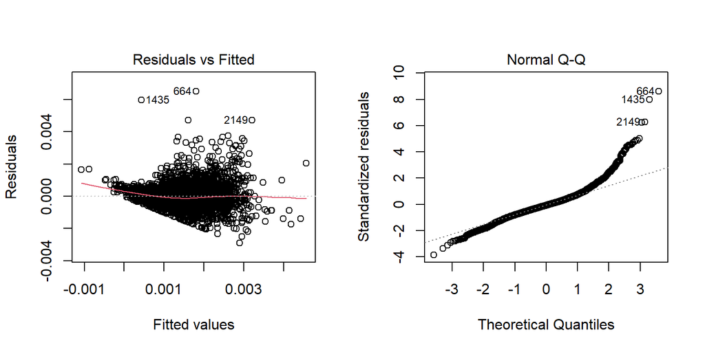

```r
par(mfrow=c(1,2))
plot(final.fit, 1)
plot(final.fit, 2)
```

22. If necessary, reduce the model from iv) to a final model with all variables being significant at 0.05 level. Are the linear model assumptions all reasonably met?

```r
all_significant <- function(selected_var_mat, y, data, alpha = 0.05) {
sapply(1:nrow(selected_var_mat),
function(x) {
selected_var_index <- selected_var_mat[x,]
var <- names(selected_var_index)[selected_var_index]
formula <- as.formula(paste0(y, "~", paste(var, collapse = "+")))
fit <- lm(formula, data)
all(summary(fit)$coef[-1, 4] < alpha)
})
}
sub <- c("UnempRate2019", "PctEmpFIRE", "PctEmpConstruction", "OwnHomePct", "Age65AndOlderPct2010", "Under18Pct2010", "Ed3SomeCollegePct", "Ed5CollegePlusPct", "NetMigrationRate1019", "NaturalChangeRate1019", "WhiteNonHispanicPct2010", "NativeAmericanNonHispanicPct2010", "BlackNonHispanicPct2010", "AsianNonHispanicPct2010", "HispanicPct2010")
subs <- X[,sub]
#subs
data2 = cbind(county_death$log_total_death_per100k, data.frame(subs))
names(data2)[1] ="log_total_death_per100k"
#data2
all_sig_fit <- lm(log_total_death_per100k ~., data = data.frame(data2))
summary(all_sig_fit)
```

```
##
## Call:
## lm(formula = log_total_death_per100k ~ ., data = data.frame(data2))
##
## Residuals:
##       Min        1Q    Median        3Q       Max
## -0.003161 -0.000519 -0.000054  0.000399  0.006227
##
## Coefficients:
##                                   Estimate Std. Error t value Pr(>|t|)
## (Intercept)                      -2.06e-02   1.81e-03  -11.36  < 2e-16 ***
## UnempRate2019                    -4.52e-05   1.28e-05   -3.53  0.00043 ***
## PctEmpFIRE                        5.52e-05   9.95e-06    5.55  3.1e-08 ***
## PctEmpConstruction               -3.15e-05   7.20e-06   -4.37  1.3e-05 ***
## OwnHomePct                       -8.06e-06   2.76e-06   -2.92  0.00352 **
## Age65AndOlderPct2010              6.63e-05   6.64e-06    9.99  < 2e-16 ***
## Under18Pct2010                    5.05e-05   7.97e-06    6.34  2.6e-10 ***
## Ed3SomeCollegePct                -2.71e-05   4.42e-06   -6.14  9.1e-10 ***
## Ed5CollegePlusPct                -1.93e-05   2.58e-06   -7.48  9.8e-14 ***
## NetMigrationRate1019             -1.46e-05   2.36e-06   -6.16  8.4e-10 ***
## NaturalChangeRate1019            -2.92e-05   9.66e-06   -3.03  0.00250 **
## WhiteNonHispanicPct2010           2.17e-04   1.84e-05   11.79  < 2e-16 ***
## NativeAmericanNonHispanicPct2010  2.51e-04   1.94e-05   12.91  < 2e-16 ***
## BlackNonHispanicPct2010           2.32e-04   1.83e-05   12.68  < 2e-16 ***
## AsianNonHispanicPct2010           2.39e-04   2.35e-05   10.17  < 2e-16 ***
## HispanicPct2010                   2.29e-04   1.83e-05   12.51  < 2e-16 ***
## ---
## Signif. codes:  0 '***' 0.001 '**' 0.01 '*' 0.05 '.' 0.1 ' ' 1
##
## Residual standard error: 0.000855 on 3047 degrees of freedom
## Multiple R-squared:  0.286,  Adjusted R-squared:  0.282
## F-statistic: 81.2 on 15 and 3047 DF,  p-value: <2e-16
```

6. It has been shown that COVID affects elderly the most. It is also claimed that the COVID death rate among African Americans and Latinos is higher. Does your analysis support these arguments?

The analysis does support these arguments, as the variables representing African Americans and Latinos (BlackNonHispanicPct2010 and HispanicPct2010) were both significant predictors, and the actual coefficient estimates were positive, implying that these populations were associated with higher COVID death rate.

7. Based on your final model, summarize your findings. In particular, summarize the state effect controlling for others. Provide intervention recommendations to policy makers to reduce COVID death rate.

There are a number of factors that are associated with higher and lower COVID death rates. Below are some particular interesting/notable factors:

Associated with higher death rates: Old age, young age, minority groups (asian, hispanic, african american). Interestingly, nonhispanic whites were also associated with higher COVID death rates.

Associated with lower death rates: Owning a home and having more education were associated with lower death rates.

For recommendations, we recommend that states look to target unemployment, as well as increase efforts towards guaranteeing the safety and care of especially young and old populations. Increased support should also go to minority groups during COVID-19, as our findings imply greater risk associations.

8. What else can we do to improve our model? What other important information we may have missed?

9. (Optional) Would your findings be very different if you had refined the data in some way or imputed the missing values in part ii). Check PCA lecture, section 10 for imputations via `softImpute`.

# 10 Executive summary

Please summarize this project as follows (no more than one page):

- Goal of the study

The goal of the study is to analyze COVID cases and COVID-related death statistics at state levels. We analyze 3 datasets involving county-level infection and fatality data, county-level socieconomic data, and intervention policy data in order to figure out county-level demographic and policy interventions that would help to reduce overall death rates from COVID.

- Data
  - Source and a brief description of the data
  - How do you assemble them together (mostly done by our team but you may present them as if you have done so)

The data comes from many different sources. 1. County-level infection and fatality data - This dataset gives daily cumulative numbers on infection and fatality for each county. 2. County-level socioeconomic data - The following are the four relevant datasets from this site. i. Income - Poverty level and household income. ii. Jobs - Employment type, rate, and change. iii. People - Population size, density, education level, race, age, household size, and migration rates. iv. County Classifications - Type of county (rural or urban on a rural-urban continuum scale). 3. Intervention Policy Data - This dataset is a manually compiled list of the dates that interventions/lockdown policies were implemented and lifted at the county level.

Data was assembled and cleaned and stored in 3 csvs: • covid_county.csv: County-level socialeconomic information that combines the above-mentioned 4 datasets: Income (Poverty level and household income), Jobs (Employment type, rate, and change), People (Population size, density, education level, race, age, household size, and migration rates), County Classifications • covid_rates.csv: Daily cumulative numbers on infection and fatality for each county • covid_intervention.csv: County-level lockdown intervention.

Additional cleaning and processing was done when needed for each part of the analyses.

- Analyses

- Methods used

In order to conduct this analyses, we employed a variety of R packages, including built in R functions for additional data cleaning, processing, and transforming, ggplot for graphs such as COVID cases by sstate and day/Weekly cases by State, etc.

- Findings

For recommendations, we recommend that states look to target unemployment, as well as increase efforts towards guaranteeing the safety and care of especially young and old populations. Increased support should also go to minority groups during COVID-19, as our findings imply that these groups are at greater risk.

- Limitations

In terms of limitations, we are only able to generate findings on reported data. If hospitals did not have the proper infrastructure for testing or did not have efficient/efficacious data entry processes, then this may impact the accuracy of our findings. Additionally, the population of each county/state changed during the study, and these changes were not properly reflected in our datasets. We are also unsure if the deaths that were tracked included indirect COVID deaths caused by hospital shutdown/overoccupancy/understaffing during the pandemic.

# 11 Appendix 1: Data description

A detailed summary of the variables in each data set follows:

## 11.1 Infection and fatality data

- date: Date
- county: County name
- state: State name
- fips: County code that uniquely identifies a county
- cases: Number of cumulative COVID-19 infections
- deaths: Number of cumulative COVID-19 deaths

## 11.2 Socioeconomic demographics

*Income*: Poverty level and household income

- PovertyUnder18Pct: Poverty rate for children age 0-17, 2018
- Deep_Pov_All: Deep poverty, 2014-18
- Deep_Pov_Children: Deep poverty for children, 2014-18
- PovertyAllAgesPct: Poverty rate, 2018
- MedHHInc: Median household income, 2018 (In 2018 dollars)
- PerCapitaInc: Per capita income in the past 12 months (In 2018 inflation adjusted dollars), 2014-18
- PovertyAllAgesNum: Number of people of all ages in poverty, 2018
- PovertyUnder18Num: Number of people age 0-17 in poverty, 2018

*Jobs*: Employment type, rate, and change

- UnempRate2007-2019: Unemployment rate, 2007-2019
- NumEmployed2007-2019: Employed, 2007-2019
- NumUnemployed2007-2019: Unemployed, 2007-2019
- PctEmpChange1019: Percent employment change, 2010-19
- PctEmpChange1819: Percent employment change, 2018-19
- PctEmpChange0719: Percent employment change, 2007-19
- PctEmpChange0710: Percent employment change, 2007-10
- NumCivEmployed: Civilian employed population 16 years and over, 2014-18
- NumCivLaborforce2007-2019: Civilian labor force, 2007-2019
- PctEmpFIRE: Percent of the civilian labor force 16 and over employed in finance and insurance, and real estate and rental and leasing, 2014-18
- PctEmpConstruction: Percent of the civilian labor force 16 and over employed in construction, 2014-18
- PctEmpTrans: Percent of the civilian labor force 16 and over employed in transportation, warehousing and utilities, 2014-18
- PctEmpMining: Percent of the civilian labor force 16 and over employed in mining, quarrying, oil and gas extraction, 2014-18
- PctEmpTrade: Percent of the civilian labor force 16 and over employed in wholesale and retail trade, 2014-18
- PctEmpInformation: Percent of the civilian labor force 16 and over employed in information services, 2014-18
- PctEmpAgriculture: Percent of the civilian labor force 16 and over employed in agriculture, forestry, fishing, and hunting, 2014-18
- PctEmpManufacturing: Percent of the civilian labor force 16 and over employed in manufacturing, 2014-18
- PctEmpServices: Percent of the civilian labor force 16 and over employed in services, 2014-18
- PctEmpGovt: Percent of the civilian labor force 16 and over employed in public administration, 2014-18

*People*: Population size, density, education level, race, age, household size, and migration rates

- PopDensity2010: Population density, 2010
- LandAreaSQMiles2010: Land area in square miles, 2010
- TotalHH: Total number of households, 2014-18
- TotalOccHU: Total number of occupied housing units, 2014-18
- AvgHHSize: Average household size, 2014-18
- OwnHomeNum: Number of owner occupied housing units, 2014-18
- OwnHomePct: Percent of owner occupied housing units, 2014-18
- NonEnglishHHPct: Percent of non-English speaking households of total households, 2014-18
- HH65PlusAlonePct: Percent of persons 65 or older living alone, 2014-18
- FemaleHHPct: Percent of female headed family households of total households, 2014-18
- FemaleHHNum: Number of female headed family households, 2014-18
- NonEnglishHHNum: Number of non-English speaking households, 2014-18
- HH65PlusAloneNum: Number of persons 65 years or older living alone, 2014-18
- Age65AndOlderPct2010: Percent of population 65 or older, 2010
- Age65AndOlderNum2010: Population 65 years or older, 2010
- TotalPop25Plus: Total population 25 and older, 2014-18 - 5-year average
- Under18Pct2010: Percent of population under age 18, 2010
- Under18Num2010: Population under age 18, 2010
- Ed1LessThanHSPct: Percent of persons with no high school diploma or GED, adults 25 and over, 2014-18
- Ed2HSDiplomaOnlyPct: Percent of persons with a high school diploma or GED only, adults 25 and over, 2014-18
- Ed3SomeCollegePct: Percent of persons with some college experience, adults 25 and over, 2014-18
- Ed4AssocDegreePct: Percent of persons with an associate’s degree, adults 25 and over, 2014-18
- Ed5CollegePlusPct: Percent of persons with a 4-year college degree or more, adults 25 and over, 2014-18
- Ed1LessThanHSNum: No high school, adults 25 and over, 2014-18
- Ed2HSDiplomaOnlyNum: High school only, adults 25 and over, 2014-18
- Ed3SomeCollegeNum: Some college experience, adults 25 and over, 2014-18
- Ed4AssocDegreeNum: Number of persons with an associate’s degree, adults 25 and over, 2014-18
- Ed5CollegePlusNum: College degree 4-years or more, adults 25 and over, 2014-18
- ForeignBornPct: Percent of total population foreign born, 2014-18
- ForeignBornEuropePct: Percent of persons born in Europe, 2014-18
- ForeignBornMexPct: Percent of persons born in Mexico, 2014-18
- ForeignBornCentralSouthAmPct: Percent of persons born in Central or South America, 2014-18
- ForeignBornAsiaPct: Percent of persons born in Asia, 2014-18
- ForeignBornCaribPct: Percent of persons born in the Caribbean, 2014-18
- ForeignBornAfricaPct: Percent of persons born in Africa, 2014-18
- ForeignBornNum: Number of people foreign born, 2014-18
- ForeignBornCentralSouthAmNum: Number of persons born in Central or South America, 2014-18
- ForeignBornEuropeNum: Number of persons born in Europe, 2014-18
- ForeignBornMexNum: Number of persons born in Mexico, 2014-18
- ForeignBornAfricaNum: Number of persons born in Africa, 2014-18
- ForeignBornAsiaNum: Number of persons born in Asia, 2014-18
- ForeignBornCaribNum: Number of persons born in the Caribbean, 2014-18
- Net_International_Migration_Rate_2010_2019: Net international migration rate, 2010-19
- Net_International_Migration_2010_2019: Net international migration, 2010-19
- Net_International_Migration_2000_2010: Net international migration, 2000-10
- Immigration_Rate_2000_2010: Net international migration rate, 2000-10
- NetMigrationRate0010: Net migration rate, 2000-10
- NetMigrationRate1019: Net migration rate, 2010-19
- NetMigrationNum0010: Net migration, 2000-10
- NetMigration1019: Net Migration, 2010-19
- NaturalChangeRate1019: Natural population change rate, 2010-19
- NaturalChangeRate0010: Natural population change rate, 2000-10
- NaturalChangeNum0010: Natural change, 2000-10
- NaturalChange1019: Natural population change, 2010-19
- TotalPop2010: Population size 4/1/2010 Census
- TotalPopEst2010: Population size 7/1/2010
- TotalPopEst2011: Population size 7/1/2011
- TotalPopEst2012: Population size 7/1/2012
- TotalPopEst2013: Population size 7/1/2013
- TotalPopEst2014: Population size 7/1/2014
- TotalPopEst2015: Population size 7/1/2015
- TotalPopEst2016: Population size 7/1/2016
- TotalPopEst2017: Population size 7/1/2017
- TotalPopEst2018: Population size 7/1/2018
- TotalPopEst2019: Population size 7/1/2019
- TotalPopACS: Total population, 2014-18 - 5-year average
- TotalPopEstBase2010: County Population estimate base 4/1/2010
- NonHispanicAsianPopChangeRate0010: Population change rate Non-Hispanic Asian, 2000-10
- PopChangeRate1819: Population change rate, 2018-19
- PopChangeRate1019: Population change rate, 2010-19
- PopChangeRate0010: Population change rate, 2000-10
- NonHispanicNativeAmericanPopChangeRate0010: Population change rate Non-Hispanic Native American, 2000-10
- HispanicPopChangeRate0010: Population change rate Hispanic, 2000-10
- MultipleRacePopChangeRate0010: Population change rate multiple race, 2000-10
- NonHispanicWhitePopChangeRate0010: Population change rate Non-Hispanic White, 2000-10
- NonHispanicBlackPopChangeRate0010: Population change rate Non-Hispanic African American, 2000-10
- MultipleRacePct2010: Percent multiple race, 2010
- WhiteNonHispanicPct2010: Percent Non-Hispanic White, 2010
- NativeAmericanNonHispanicPct2010: Percent Non-Hispanic Native American, 2010
- BlackNonHispanicPct2010: Percent Non-Hispanic African American, 2010
- AsianNonHispanicPct2010: Percent Non-Hispanic Asian, 2010
- HispanicPct2010: Percent Hispanic, 2010
- MultipleRaceNum2010: Population size multiple race, 2010
- WhiteNonHispanicNum2010: Population size Non-Hispanic White, 2010
- BlackNonHispanicNum2010: Population size Non-Hispanic African American, 2010
- NativeAmericanNonHispanicNum2010: Population size Non-Hispanic Native American, 2010
- AsianNonHispanicNum2010: Population size Non-Hispanic Asian, 2010
- HispanicNum2010: Population size Hispanic, 2010

##County classifications

Type of county (rural or urban on a rural-urban continuum scale)

- Type_2015_Recreation_NO: Recreation counties, 2015 edition
- Type_2015_Farming_NO: Farming-dependent counties, 2015 edition
- Type_2015_Mining_NO: Mining-dependent counties, 2015 edition
- Type_2015_Government_NO: Federal/State government-dependent counties, 2015 edition
- Type_2015_Update: County typology economic types, 2015 edition
- Type_2015_Manufacturing_NO: Manufacturing-dependent counties, 2015 edition
- Type_2015_Nonspecialized_NO: Nonspecialized counties, 2015 edition
- RecreationDependent2000: Nonmetro recreation-dependent, 1997-00
- ManufacturingDependent2000: Manufacturing-dependent, 1998-00
- FarmDependent2003: Farm-dependent, 1998-00
- EconomicDependence2000: Economic dependence, 1998-00
- RuralUrbanContinuumCode2003: Rural-urban continuum code, 2003
- UrbanInfluenceCode2003: Urban influence code, 2003
- RuralUrbanContinuumCode2013: Rural-urban continuum code, 2013
- UrbanInfluenceCode2013: Urban influence code, 2013
- Noncore2013: Nonmetro noncore, outside Micropolitan and Metropolitan, 2013
- Micropolitan2013: Micropolitan, 2013
- Nonmetro2013: Nonmetro, 2013
- Metro2013: Metro, 2013
- Metro_Adjacent2013: Nonmetro, adjacent to metro area, 2013
- Noncore2003: Nonmetro noncore, outside Micropolitan and Metropolitan, 2003
- Micropolitan2003: Micropolitan, 2003
- Metro2003: Metro, 2003
- Nonmetro2003: Nonmetro, 2003
- NonmetroNotAdj2003: Nonmetro, nonadjacent to metro area, 2003
- NonmetroAdj2003: Nonmetro, adjacent to metro area, 2003
- Oil_Gas_Change: Change in the value of onshore oil and natural gas production, 2000-11
- Gas_Change: Change in the value of onshore natural gas production, 2000-11
- Oil_Change: Change in the value of onshore oil production, 2000-11
- Hipov: High poverty counties, 2014-18
- Perpov_1980_0711: Persistent poverty counties, 2015 edition
- PersistentChildPoverty_1980_2011: Persistent child poverty counties, 2015 edition
- PersistentChildPoverty2004: Persistent child poverty counties, 2004
- PersistentPoverty2000: Persistent poverty counties, 2004
- Low_Education_2015_update: Low education counties, 2015 edition
- LowEducation2000: Low education, 2000
- HiCreativeClass2000: Creative class, 2000
- HiAmenity: High natural amenities
- RetirementDestination2000: Retirement destination, 1990-00
- Low_Employment_2015_update: Low employment counties, 2015 edition
- Population_loss_2015_update: Population loss counties, 2015 edition
- Retirement_Destination_2015_Update: Retirement destination counties, 2015 edition

# 12 Appendix 2: Data cleaning

The raw data sets are dirty and need transforming before we can do our EDA. It takes time and efforts to clean and merge different data sources so we provide the final output of the cleaned and merged data. The cleaning procedure is as follows. Please read through to understand what is in the cleaned data. We set `eval = data_cleaned` in the following cleaning chunks so that these cleaning chunks will only run if any of `data/covid_county.csv`, `data/covid_rates.csv` or `data/covid_intervention.csv` does not exist.

```r
# Indicator to check whether the data files exist
data_cleaned <- !(file.exists("data/covid_county.csv") &
                    file.exists("data/covid_rates.csv") &
                    file.exists("data/covid_intervention.csv"))
```

We first read in the table using `data.table::fread()`, as we did last time.

```r
# COVID case/mortality rate data
covid_rates <- fread("data/us_counties.csv", na.strings = c("NA", "", "."))
nyc <- fread("data/nycdata.csv", na.strings = c("NA", "", "."))

# Socioeconomic data
income <- fread("data/income.csv", na.strings = c("NA", "", "."))
jobs <- fread("data/jobs.csv", na.strings = c("NA", "", "."))
people <- fread("data/people.csv", na.strings = c("NA", "", "."))
county_class <- fread("data/county_classifications.csv", na.strings = c("NA", "", "."))

# Internvention policy data
int_dates <- fread("data/intervention_dates.csv", na.strings = c("NA", "", "."))
```

## 12.1 Clean NYC data

The original NYC data contains more information than we need. We extract only the number of cases and deaths and format it the same as the `covid_rates` data.

```r
# NYC county fips matching table
nyc_fips <- data.table(FIPS = c('36005', '36047', '36061', '36081', '36085'),
                       County = c("BX", "BK", "MN", "QN", "SI"))

# nyc case
nyc_case <- nyc[,.(date = as.Date(date_of_interest, "%m/%d/%Y"),
                   BX = BX_CASE_COUNT,
                   BK = BK_CASE_COUNT,
                   MN = MN_CASE_COUNT,
                   QN = QN_CASE_COUNT,
                   SI = SI_CASE_COUNT)]

nyc_case %<>%
  pivot_longer(cols = BX:SI,
               names_to = "County",
               values_to = "cases") %>%
  arrange(date) %>%
  group_by(County) %>%
  mutate(cum_cases = cumsum(cases))

# nyc death
nyc_death <- nyc[,.(date = as.Date(date_of_interest, "%m/%d/%Y"),
                   BX = BX_DEATH_COUNT,
                   BK = BK_DEATH_COUNT,
                   MN = MN_DEATH_COUNT,
                   QN = QN_DEATH_COUNT,
                   SI = SI_DEATH_COUNT)]

nyc_death %<>%
  pivot_longer(cols = BX:SI,
               names_to = "County",
               values_to = "deaths") %>%
  arrange(date) %>%
  group_by(County) %>%
  mutate(cum_deaths = cumsum(deaths))

nyc_rates <- merge(nyc_case,
                   nyc_death,
                   by = c("date", "County"),
                   all.x= T)

nyc_rates <- merge(nyc_rates,
                   nyc_fips,
                   by = "County")

nyc_rates$State <- "New York"
nyc_rates %<>%
  select(date, FIPS, County, State, cum_cases, cum_deaths) %>%
  arrange(FIPS, date)
```

## 12.2 Continental US cases

We only consider cases and death in continental US. Alaska, Hawaii, and Puerto Rico have 02, 15, and 72 as their respective first 2 digits of their FIPS. We use the `%/%` operator for integer division to get the first 2 digits of FIPS. We also remove Virgin Islands and Northern Mariana Islands. All data of counties in NYC are aggregated as `County == "New York City"` in `covid_rates` with no FIPS, so we combine the NYC data into `covid_rate`.

```r
covid_rates <- covid_rates %>%
  arrange(fips, date) %>%
  filter(!(fips %/% 1000 %in% c(2, 15, 72))) %>%
  filter(county != "New York City") %>%
  filter(!(state %in% c("Virgin Islands", "Northern Mariana Islands"))) %>%
  rename(FIPS = "fips",
         County = "county",
         State = "state",
         cum_cases = "cases",
         cum_deaths = "deaths")


covid_rates$date <- as.Date(covid_rates$date)

covid_rates <- rbind(covid_rates,
                     nyc_rates)
```

## 12.3 COVID date to week

We set the week of Jan 21, 2020 (the first case of COVID case in US) as the first week (2020-01-19 to 2020-01-25).

```r
covid_rates[, week := (interval("2020-01-19", date) %/% weeks(1)) + 1]
```

## 12.4 COVID infection/mortality rates

Merge the `TotalPopEst2019` variable from the demographic data with `covid_rates` by FIPS.

```r
covid_rates <- merge(covid_rates[!is.na(FIPS)],
                     people[,.(FIPS = as.character(FIPS),
                                   TotalPopEst2019)],
                     by = "FIPS",
                     all.x = TRUE)
```

## 12.5 NA in COVID data

NA values in the `covid_rates` data set correspond to a county not having confirmed cases/deaths. We replace the NA values in these columns with zeros. FIPS for Kansas city, Missouri, Rhode Island and some others are missing. We drop them for the moment and output the data up to week 57 as `covid_rates.csv`.

```r
covid_rates$cum_cases[is.na(covid_rates$cum_cases)] <- 0
covid_rates$cum_deaths[is.na(covid_rates$cum_deaths)] <- 0
```

```r
fwrite(covid_rates %>%
         filter(week < 58) %>%
         arrange(FIPS, date),
       "data/covid_rates.csv")
```

## 12.6 Formatting date in `int_dates`

We convert the columns representing dates in `int_dates` to R Date types using `as.Date()`. We will need to specify that the `origin` parameter is `"0001-01-01"`. We output the data as `covid_intervention.csv`.

```r
int_dates <- int_dates[-1,]
date_cols <- names(int_dates)[-(1:3)]
int_dates[, (date_cols) := lapply(.SD, as.Date, origin = "0001-01-01"),
          .SDcols = date_cols]

fwrite(int_dates, "data/covid_intervention.csv")
```

## 12.7 Merge demographic data

Merge the demographic data sets by FIPS and output as `covid_county.csv`.

```r
countydata <-
  merge(x = income,
        y = merge(
          x = people,
          y = jobs,
          by = c("FIPS", "State", "County")),
        by = c("FIPS", "State", "County"),
        all = TRUE)


countydata <-
  merge(
    x = countydata,
    y = county_class %>% rename(FIPS = FIPStxt),
    by = c("FIPS", "State", "County"),
    all = TRUE
  )

# Check dimensions
# They are now 3279 x 208
dim(countydata)
fwrite(countydata, "data/covid_county.csv")
```